# Collar County Analysis

##### Will County

```r
will_agencies <- toupper(c(
  "Will County Sheriff",
  "Woodridge Police",
  "Wilmington Police",
  "University Park Police",
  "Tinley Park Police",
  "Steger Police",
  "Shorewood Police",
  "Romeoville Police",
  "Rockdale Police",
  "Plainfield Police",
  "Peotone Police",
  "Orland Park Police",
  "New Lenox Police",
  "Monee Police",
  "Mokena Police",
  "Manhattan Police",
  "Lockport Police",
  "Lemont Police",
  "Joliet Police",
  "Homer Glen Police",
  "Frankfort Police",
  "Elwood Police",
  "Coal City Police",
  "Channahon Police",
  "Braidwood Police",
  "Bolingbrook Police",
  "Beecher Police",
  "Crest Hill Police"




  ))
```

```r
will_law <- traffic_24 %>%
  mutate(agency_name = str_squish(agency_name)) %>%
  filter(agency_name %in% will_agencies)
```

```r
will_law %>%
  count(agency_name, sort = TRUE)
```

```
##                agency_name     n
##                     <char> <int>
##  1:     BOLINGBROOK POLICE 19289
##  2:          JOLIET POLICE 11050
##  3:      ROMEOVILLE POLICE  9933
##  4:       NEW LENOX POLICE  9296
##  5:    WILL COUNTY SHERIFF  9225
##  6:     ORLAND PARK POLICE  7256
##  7:       FRANKFORT POLICE  6906
##  8:      PLAINFIELD POLICE  6606
##  9:       MANHATTAN POLICE  5250
## 10:     TINLEY PARK POLICE  5249
## 11:        LOCKPORT POLICE  5001
## 12:       SHOREWOOD POLICE  4527
## 13:       WOODRIDGE POLICE  3957
## 14:      CREST HILL POLICE  3888
## 15:         BEECHER POLICE  3209
## 16:       COAL CITY POLICE  3149
## 17:          LEMONT POLICE  3077
## 18:          MOKENA POLICE  2906
## 19:           MONEE POLICE  2214
## 20:          ELWOOD POLICE  2028
## 21:       CHANNAHON POLICE  2020
## 22:       BRAIDWOOD POLICE  1188
## 23:        ROCKDALE POLICE  1090
## 24:          STEGER POLICE   498
## 25: UNIVERSITY PARK POLICE    54
##                agency_name     n
##                     <char> <int>
```

```r
will_pop <- data.frame(
  race = c("White", "Black", "Hispanic", "Asian", "American Indian", "NHPI"),
  population_pct = c(74, 12.9, 21.1, 7.8, 1.6, 0.1)
)
```

```r
## getting the traffic stop percentage by each race, bringing in lake county population percentage
will_stops <- will_law %>%
  count(race, sort = TRUE) |>
  mutate(stop_pct = n / sum(n) * 100)

will_stops <- will_stops |>
  left_join(will_pop, by ="race")

will_stops
```

```
##               race     n   stop_pct population_pct
##             <char> <int>      <num>          <num>
## 1:           White 62761 48.7025282           74.0
## 2:           Black 32936 25.5583319           12.9
## 3:        Hispanic 29002 22.5055484           21.1
## 4:           Asian  3331  2.5848556            7.8
## 5: American Indian   445  0.3453199            1.6
## 6:            NHPI   391  0.3034160            0.1
```

- Black and Hispanic drivers are overrepresented in traffic stops relative to their share of the population. Whiteand Asian drivers are underrepresented in traffic stops relative to their share of the population.

```r
## reformatting it
will_plot <- will_stops %>%
  select(race, stop_pct, population_pct) %>%
  pivot_longer(
    cols = c(stop_pct, population_pct),
    names_to = "type",
    values_to = "percent"
  )
```

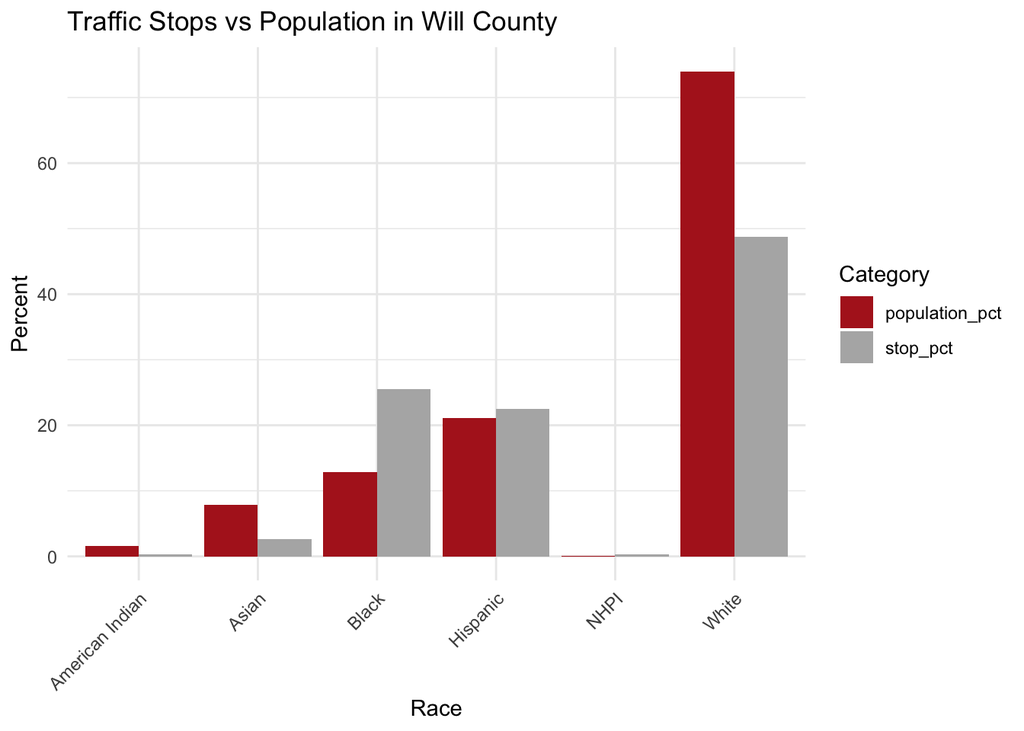

```r
## graphing it
ggplot(will_plot, aes(x = race, y = percent, fill = type)) +
  geom_col(position = "dodge") +
  scale_fill_manual(values = c(
    "stop_pct" = "grey70",
    "population_pct" = "#B22222"
  )) +
  labs(
    title = "Traffic Stops vs Population in Will County",
    x = "Race",
    y = "Percent",
    fill = "Category"
  ) +
  theme_minimal() +
  theme(axis.text.x = element_text(angle = 45, hjust = 1))
```

```r
### creating a new data table that has the total number of stops by race and then getting the number of searches that was conducted, creating a rate by taking searches divided by total stops and multiplying by 100 to get a percentage
will_search_rates <- will_law |>
  group_by(race) |>
  summarise(
    total_stops = n(),
    searches = sum(vehicle_search_conducted == "Yes", na.rm = TRUE),
    search_rate = searches/ total_stops * 100
  )


will_search_rates
```

```
## # A tibble: 6 × 4
##   race            total_stops searches search_rate
##   <chr>                 <int>    <int>       <dbl>
## 1 American Indian         445        5       1.12
## 2 Asian                  3331       27       0.811
## 3 Black                 32936     1735       5.27
## 4 Hispanic              29002     1011       3.49
## 5 NHPI                    391       19       4.86
## 6 White                 62761      898       1.43
```

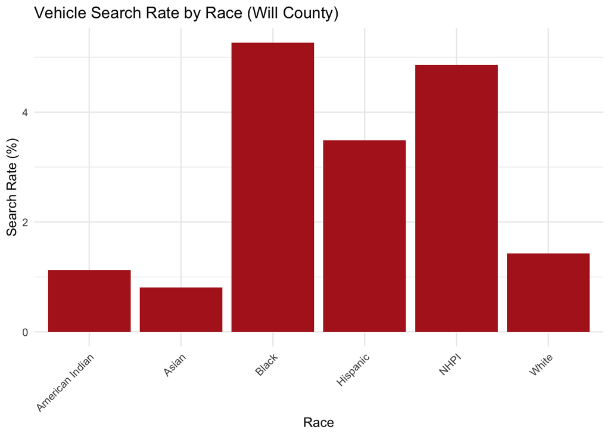

```r
ggplot(will_search_rates, aes(x = race, y = search_rate)) +
  geom_col(fill = "#B22222") +
  labs(
    title = "Vehicle Search Rate by Race (Will County)",
    x = "Race",
    y = "Search Rate (%)"
  ) +
  theme_minimal() +
  theme(axis.text.x = element_text(angle = 45, hjust = 1))
```

###### Top 3 Will County Law Enforcment Agencies

- BOLINGBROOK POLICE 19289
- JOLIET POLICE 11050
- ROMEOVILLE POLICE 9933

###### Bolingbrook Police

```r
## bringing in McHenry City data
bolingbrook_pop <- data.frame(
  race = c("White", "Black", "Hispanic", "Asian", "American Indian", "NHPI"),
  population_pct = c(39.1, 16, 28.9, 14.3, 1, 0)
)
```

```r
bolingbrook_city <- will_law |>
  filter(agency_name == "BOLINGBROOK POLICE") |>
  count(race) |>
  mutate(stop_pct = n/sum(n) * 100)

bolingbrook_city <- bolingbrook_city|>
  left_join(bolingbrook_pop, by ="race")

bolingbrook_city
```

```
##               race     n   stop_pct population_pct
##             <char> <int>      <num>          <num>
## 1: American Indian   178  0.9228057            1.0
## 2:           Asian  1222  6.3352170           14.3
## 3:           Black  6288 32.5988906           16.0
## 4:        Hispanic  6025 31.2354192           28.9
## 5:            NHPI    65  0.3369796            0.0
## 6:           White  5511 28.5706880           39.1
```

- Black and Hispanic drivers are overrepresented in traffic stops relative to their share of the population, while White and Asian drivers are underrepresented.

```r
## graphing it
bolingbrook_city_plot <- bolingbrook_city %>%
  select(race, stop_pct, population_pct) %>%
  pivot_longer(
    cols = c(stop_pct, population_pct),
    names_to = "type",
    values_to = "percent"
  )
```

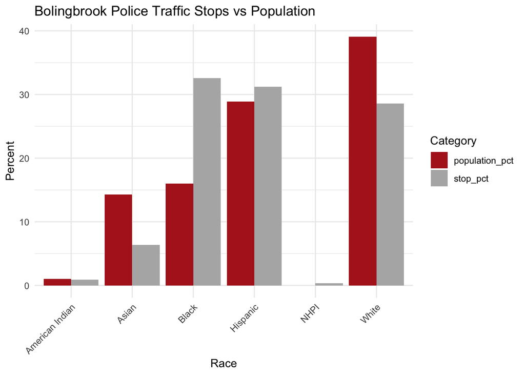

```r
## graphing it
ggplot(bolingbrook_city_plot, aes(x = race, y = percent, fill = type)) +
  geom_col(position = "dodge") +
  scale_fill_manual(values = c(
    "stop_pct" = "grey70",
    "population_pct" = "#B22222"
  )) +
  labs(
    title = "Bolingbrook Police Traffic Stops vs Population",
    x = "Race",
    y = "Percent",
    fill = "Category"
  ) +
  theme_minimal() +
  theme(axis.text.x = element_text(angle = 45, hjust = 1))
```

```r
### creating a new data table that has the total number of stops by race and then getting the number of searches that was conducted, creating a rate by taking searches divided by total stops and multiplying by 100 to get a percentage
bolingbrook_search_rates <- will_law |>
  filter(agency_name == "BOLINGBROOK POLICE") |>
  group_by(race) |>
  summarise(
    total_stops = n(),
    searches = sum(vehicle_search_conducted == "Yes", na.rm = TRUE),
    search_rate = searches/ total_stops * 100
  )

bolingbrook_search_rates
```

```
## # A tibble: 6 × 4
##   race            total_stops searches search_rate
##   <chr>                 <int>    <int>       <dbl>
## 1 American Indian         178        0       0
## 2 Asian                  1222        9       0.736
## 3 Black                  6288      339       5.39
## 4 Hispanic               6025      183       3.04
## 5 NHPI                     65        5       7.69
## 6 White                  5511       77       1.40
```

- NHPI has the highest search rate (small numbers (7.7), followed by Black drivers have the highest search rates (5.4), then Hispanic drivers (3) and then white drivers (1.4).

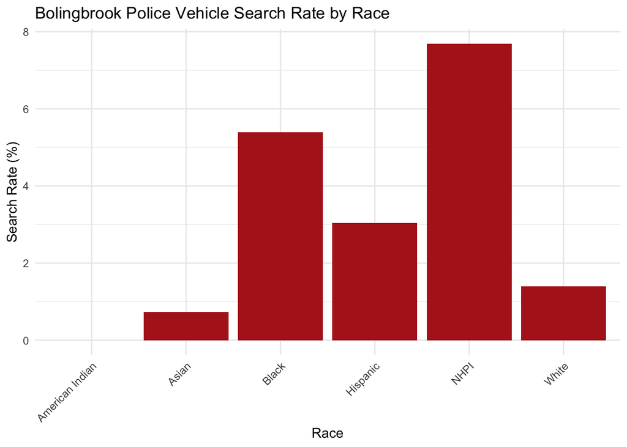

```r
ggplot(bolingbrook_search_rates, aes(x = race, y = search_rate)) +
  geom_col(fill = "#B22222") +
  labs(
    title = "Bolingbrook Police Vehicle Search Rate by Race",
    x = "Race",
    y = "Search Rate (%)"
  ) +
  theme_minimal() +
  theme(axis.text.x = element_text(angle = 45, hjust = 1))
```

###### Joliet Police

```r
## bringing in McHenry City data
joliet_pop <- data.frame(
  race = c("White", "Black", "Hispanic", "Asian", "American Indian", "NHPI"),
  population_pct = c(49.9, 16.3, 34.2, 2.5, 0.0, 0)
)
```

```r
joliet_city <- will_law |>
  filter(agency_name == "JOLIET POLICE") |>
  count(race) |>
  mutate(stop_pct = n/sum(n) * 100)

joliet_city <- joliet_city |>
  left_join(joliet_pop, by ="race")

joliet_city
```

```
##               race     n   stop_pct population_pct
##             <char> <int>      <num>          <num>
## 1: American Indian    20  0.1809955            0.0
## 2:           Asian    90  0.8144796            2.5
## 3:           Black  3575 32.3529412           16.3
## 4:        Hispanic  4260 38.5520362           34.2
## 5:            NHPI    38  0.3438914            0.0
## 6:           White  3067 27.7556561           49.9
```

- Black and Hispanic drivers are overrepresented in traffic stops relative to their share of the population, while White and Asian drivers are underrepresented.

```r
## graphing it
joliet_plot <- joliet_city %>%
  select(race, stop_pct, population_pct) %>%
  pivot_longer(
    cols = c(stop_pct, population_pct),
    names_to = "type",
    values_to = "percent"
  )
```

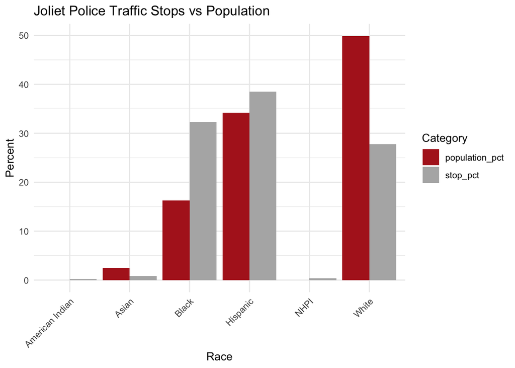

```r
## graphing it
ggplot(joliet_plot, aes(x = race, y = percent, fill = type)) +
  geom_col(position = "dodge") +
  scale_fill_manual(values = c(
    "stop_pct" = "grey70",
    "population_pct" = "#B22222"
  )) +
  labs(
    title = "Joliet Police Traffic Stops vs Population",
    x = "Race",
    y = "Percent",
    fill = "Category"
  ) +
  theme_minimal() +
  theme(axis.text.x = element_text(angle = 45, hjust = 1))
```

```r
### creating a new data table that has the total number of stops by race and then getting the number of searches that was conducted, creating a rate by taking searches divided by total stops and multiplying by 100 to get a percentage
joliet_search_rates <- will_law |>
  filter(agency_name == "JOLIET POLICE") |>
  group_by(race) |>
  summarise(
    total_stops = n(),
    searches = sum(vehicle_search_conducted == "Yes", na.rm = TRUE),
    search_rate = searches/ total_stops * 100
  )

joliet_search_rates
```

```
## # A tibble: 6 × 4
##   race            total_stops searches search_rate
##   <chr>                 <int>    <int>       <dbl>
## 1 American Indian          20        2       10
## 2 Asian                    90        1        1.11
## 3 Black                  3575      419       11.7
## 4 Hispanic               4260      314        7.37
## 5 NHPI                     38        4       10.5
## 6 White                  3067      103        3.36
```

- Black drivers have the highest search rate (11.7), followed by NHPI (small numbers 10.5), then American Indian (small numbers 10), and then Hispanic (7.4), and then white drivers (3.4).

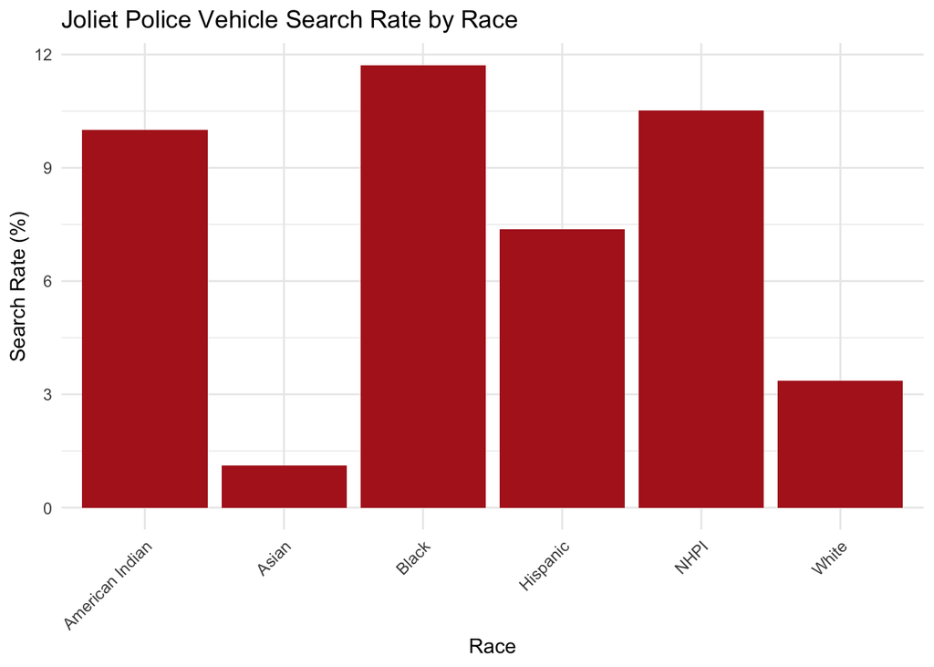

```r
ggplot(joliet_search_rates, aes(x = race, y = search_rate)) +
  geom_col(fill = "#B22222") +
  labs(
    title = "Joliet Police Vehicle Search Rate by Race",
    x = "Race",
    y = "Search Rate (%)"
  ) +
  theme_minimal() +
  theme(axis.text.x = element_text(angle = 45, hjust = 1))
```

###### Romeoville Police

```r
## bringing in McHenry City data
romeoville_pop <- data.frame(
  race = c("White", "Black", "Hispanic", "Asian", "American Indian", "NHPI"),
  population_pct = c(44.9, 14.3, 35.7, 6.5, 1, 0)
)
```

```r
romeoville_city <- will_law |>
  filter(agency_name == "ROMEOVILLE POLICE") |>
  count(race) |>
  mutate(stop_pct = n/sum(n) * 100)

romeoville_city <- romeoville_city |>
  left_join(romeoville_pop, by ="race")

romeoville_city
```

```
##               race     n   stop_pct population_pct
##             <char> <int>      <num>          <num>
## 1: American Indian    41  0.4127655            1.0
## 2:           Asian   315  3.1712474            6.5
## 3:           Black  2600 26.1753750           14.3
## 4:        Hispanic  3323 33.4541428           35.7
## 5:            NHPI    53  0.5335750            0.0
## 6:           White  3601 36.2528944           44.9
```

```r
## graphing it
romeoville_plot <- romeoville_city %>%
  select(race, stop_pct, population_pct) %>%
  pivot_longer(
    cols = c(stop_pct, population_pct),
    names_to = "type",
    values_to = "percent"
  )
```

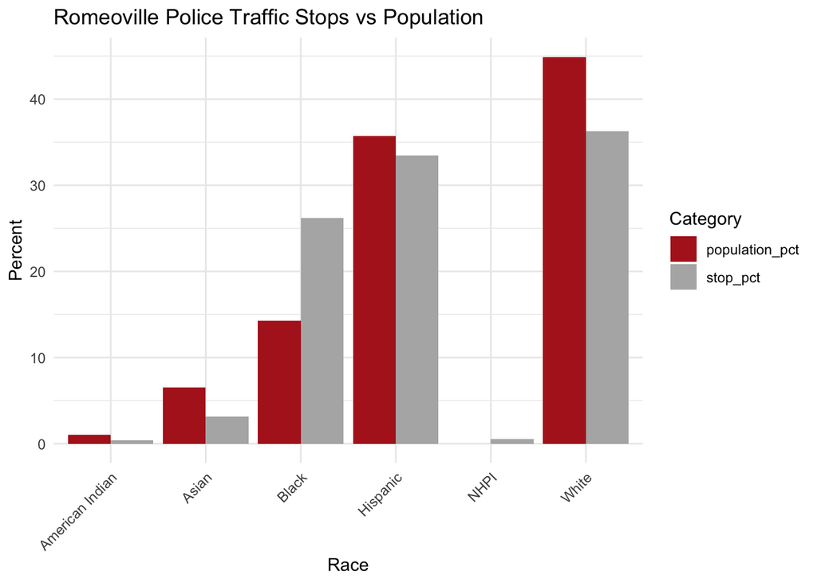

```r
## graphing it
ggplot(romeoville_plot, aes(x = race, y = percent, fill = type)) +
  geom_col(position = "dodge") +
  scale_fill_manual(values = c(
    "stop_pct" = "grey70",
    "population_pct" = "#B22222"
  )) +
  labs(
    title = "Romeoville Police Traffic Stops vs Population",
    x = "Race",
    y = "Percent",
    fill = "Category"
  ) +
  theme_minimal() +
  theme(axis.text.x = element_text(angle = 45, hjust = 1))
```

```r
### creating a new data table that has the total number of stops by race and then getting the number of searches that was conducted, creating a rate by taking searches divided by total stops and multiplying by 100 to get a percentage
romeoville_search_rates <- will_law |>
  filter(agency_name == "ROMEOVILLE POLICE") |>
  group_by(race) |>
  summarise(
    total_stops = n(),
    searches = sum(vehicle_search_conducted == "Yes", na.rm = TRUE),
    search_rate = searches/ total_stops * 100
  )

romeoville_search_rates
```

```
## # A tibble: 6 × 4
##   race            total_stops searches search_rate
##   <chr>                 <int>    <int>       <dbl>
## 1 American Indian          41        1       2.44
## 2 Asian                   315        3       0.952
## 3 Black                  2600       62       2.38
## 4 Hispanic               3323       61       1.84
## 5 NHPI                     53        0       0
## 6 White                  3601       34       0.944
```

- American Indian has the highest search rate (small numbers 2.4), followed by Black drivers (2.38), and then Hispanic drivers (1.8), and then Asian drivers (0.95), and then white drivers (0.94).

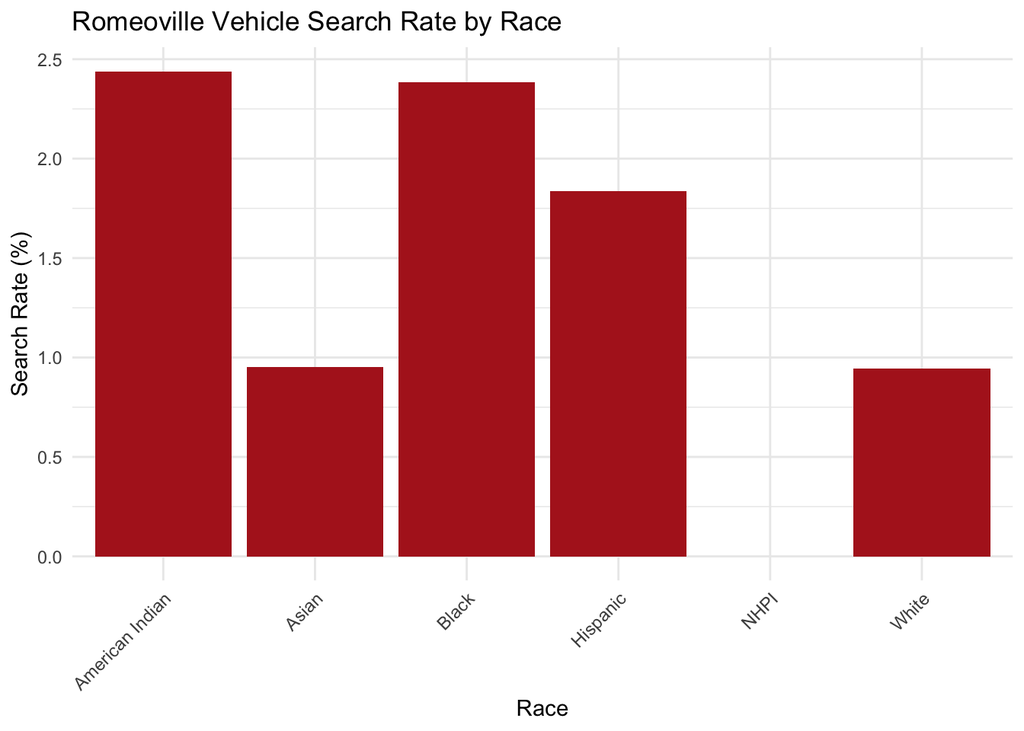

```r
ggplot(romeoville_search_rates, aes(x = race, y = search_rate)) +
  geom_col(fill = "#B22222") +
  labs(
    title = "Romeoville Vehicle Search Rate by Race",
    x = "Race",
    y = "Search Rate (%)"
  ) +
  theme_minimal() +
  theme(axis.text.x = element_text(angle = 45, hjust = 1))
```

###### Rockdale Police (row 118 in sheets)

```r
## bringing in McHenry City data
rockdale_pop <- data.frame(
  race = c("White", "Black", "Hispanic", "Asian", "American Indian", "NHPI"),
  population_pct = c(39.5, 3.25, 13.1, 1.84, 5.6, 0)
)
```

```r
rockdale_city <- will_law |>
  filter(agency_name == "ROCKDALE POLICE") |>
  count(race) |>
  mutate(stop_pct = n/sum(n) * 100)

rockdale_city <- rockdale_city |>
  left_join(rockdale_pop, by ="race")

rockdale_city
```

```
##        race     n   stop_pct population_pct
##      <char> <int>      <num>          <num>
## 1:    Asian     8  0.7339450           1.84
## 2:    Black   280 25.6880734           3.25
## 3: Hispanic   400 36.6972477          13.10
## 4:     NHPI     2  0.1834862           0.00
## 5:    White   400 36.6972477          39.50
```

```r
### creating a new data table that has the total number of stops by race and then getting the number of searches that was conducted, creating a rate by taking searches divided by total stops and multiplying by 100 to get a percentage
rockdale_search_rates <- will_law |>
  filter(agency_name == "ROCKDALE POLICE") |>
  group_by(race) |>
  summarise(
    total_stops = n(),
    searches = sum(vehicle_search_conducted == "Yes", na.rm = TRUE),
    search_rate = searches/ total_stops * 100
  )

rockdale_search_rates
```

```
## # A tibble: 5 × 4
##   race     total_stops searches search_rate
##   <chr>          <int>    <int>       <dbl>
## 1 Asian              8        0        0
## 2 Black            280       19        6.79
## 3 Hispanic         400       34        8.5
## 4 NHPI               2        0        0
## 5 White            400       11        2.75
```

##### Cook County

```r
cook_agencies <- toupper(c(
  "Alsip Police",
  "Arlington Heights Police",
  "Barrington Police",
  "Bedford Park Police",
  "Bellwood Police",
  "Berkeley Police",
  "Berwyn Police",
  "Blue Island Police",
  "Bridgeview Police",
  "Broadview Police",
  "Brookfield Police",
  "Buffalo Grove Police",
  "Burbank Police",
  "Burnham Police",
  "Calumet City Police",
  "Chicago Police",
  "Chicago Heights Police",
  "Chicago Ridge Police",
  "Cicero Police",
  "Country Club Hills Police",
  "Countryside Police",
  "Crestwood Police",
  "Des Plaines Police",
  "Dolton Police",
  "East Dundee Police",
  "Elk Grove Village Police",
  "Elmwood Park Police",
  "Evanston Police",
  "Evergreen Park Police",
  "Flossmoor Police",
  "Forest Park Police",
  "Franklin Park Police",
  "Glencoe Police",
  "Glenview Police",
  "Golf Police",
  "Harvey Police",
  "Harwood Heights Police",
  "Hazel Crest Police",
  "Hickory Hills Police",
  "Hillside Police",
  "Hines Police",
  "Hodgkins Police",
  "Hoffman Estates Police",
  "Hometown Police",
  "Homewood Police",
  "Indian Head Park Police",
  "Justice Police",
  "Kenilworth Police",
  "La Grange Police",
  "La Grange Park Police",
  "Lansing Police",
  "Lincolnwood Police",
  "Lyons Police",
  "Markham Police",
  "Maywood Police",
  "McCook Police",
  "Melrose Park Police",
  "Midlothian Police",
  "Morton Grove Police",
  "Mount Prospect Police",
  "Niles Police",
  "Norridge Police",
  "Northbrook Police",
  "Northfield Police",
  "Oak Forest Police",
  "Oak Lawn Police",
  "Oak Park Police",
  "Olympia Fields Police",
  "Orland Park Police",
  "Palatine Police",
  "Palos Heights Police",
  "Palos Hills Police",
  "Palos Park Police",
  "Park Forest Police",
  "Park Ridge Police",
  "Phoenix Police",
  "Posen Police",
  "Prospect Heights Police",
  "Richton Park Police",
  "River Forest Police",
  "River Grove Police",
  "Riverdale Police",
  "Riverside Police",
  "Robbins Police",
  "Rolling Meadows Police",
  "Rosemont Police",
  "Schaumburg Police",
  "Schiller Park Police",
  "Skokie Police",
  "South Barrington Police",
  "South Chicago Heights Police",
  "South Holland Police",
  "Stickney Police",
  "Stone Park Police",
  "Streamwood Police",
  "Summit Police",
  "Thornton Police",
  "Tinley Park Police",
  "Westchester Police",
  "Western Springs Police",
  "Westmont Police",
  "Wheeling Police",
  "Willow Springs Police",
  "Wilmette Police",
  "Winnetka Police",
  "Worth Police",
  "Cook County Sheriff",
  "Cook County Forest Preserve Police"
))
```

```r
cook_law <- traffic_24 %>%
  mutate(agency_name = str_squish(agency_name)) %>%
  filter(agency_name %in% cook_agencies)
```

```r
cook_law %>%
  count(agency_name, sort = TRUE)
```

```
##                            agency_name     n
##                                 <char> <int>
##  1:                COOK COUNTY SHERIFF 56095
##  2:                  SCHAUMBURG POLICE 23916
##  3:                    PALATINE POLICE 19314
##  4:                    WHEELING POLICE 16608
##  5:              EVERGREEN PARK POLICE 13769
##  6:                    OAK LAWN POLICE 12945
##  7:              MOUNT PROSPECT POLICE 12257
##  8:           ELK GROVE VILLAGE POLICE 10565
##  9:                       ALSIP POLICE 10149
## 10:               BUFFALO GROVE POLICE  8596
## 11:             HOFFMAN ESTATES POLICE  8014
## 12:                      BERWYN POLICE  7966
## 13:                 BLUE ISLAND POLICE  7408
```

[output cut: 88 more lines]

```r
cook_pop <- data.frame(
  race = c("White", "Black", "Hispanic", "Asian", "American Indian", "NHPI"),
  population_pct = c(61.2, 22.8, 27.8, 9.1, 3, 0.1)
)
```

```r
## getting the traffic stop percentage by each race, bringing in lake county population percentage
cook_stops <- cook_law %>%
  count(race, sort = TRUE) |>
  mutate(stop_pct = n / sum(n) * 100)

cook_stops <- cook_stops |>
  left_join(cook_pop, by ="race")

cook_stops
```

```
##               race      n   stop_pct population_pct
##             <char>  <int>      <num>          <num>
## 1:           White 182645 42.5395886           61.2
## 2:           Black 113900 26.5282879           22.8
## 3:        Hispanic 102473 23.8668415           27.8
## 4:           Asian  26492  6.1702143            9.1
## 5: American Indian   2335  0.5438415            3.0
## 6:            NHPI   1508  0.3512261            0.1
```

```r
## reformatting it
cook_plot <- cook_stops %>%
  select(race, stop_pct, population_pct) %>%
  pivot_longer(
    cols = c(stop_pct, population_pct),
    names_to = "type",
    values_to = "percent"
  )
```

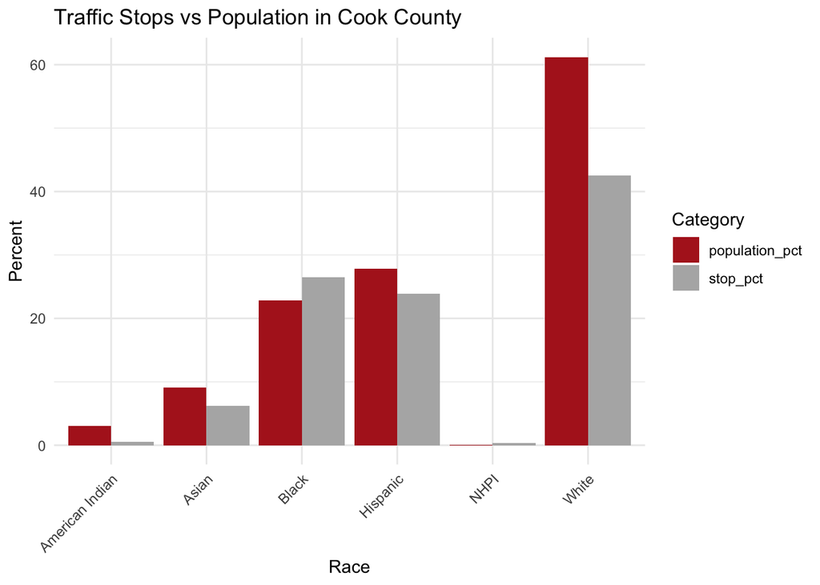

```r
## graphing it
ggplot(cook_plot, aes(x = race, y = percent, fill = type)) +
  geom_col(position = "dodge") +
  scale_fill_manual(values = c(
    "stop_pct" = "grey70",
    "population_pct" = "#B22222"
  )) +
  labs(
    title = "Traffic Stops vs Population in Cook County",
    x = "Race",
    y = "Percent",
    fill = "Category"
  ) +
  theme_minimal() +
  theme(axis.text.x = element_text(angle = 45, hjust = 1))
```

```r
### creating a new data table that has the total number of stops by race and then getting the number of searches that was conducted, creating a rate by taking searches divided by total stops and multiplying by 100 to get a percentage
cook_search_rates <- cook_law |>
  group_by(race) |>
  summarise(
    total_stops = n(),
    searches = sum(vehicle_search_conducted == "Yes", na.rm = TRUE),
    search_rate = searches/ total_stops * 100
  )


cook_search_rates
```

```
## # A tibble: 6 × 4
##   race            total_stops searches search_rate
##   <chr>                 <int>    <int>       <dbl>
## 1 American Indian        2335       26       1.11
## 2 Asian                 26492      176       0.664
## 3 Black                113900     5924       5.20
## 4 Hispanic             102473     3940       3.84
## 5 NHPI                   1508       36       2.39
## 6 White                182645     1993       1.09
```

- Black drivers have the highest search rates (5.2), followed by Hispanic drivers (3.8), followed by NHPI drivers (small numbers, but 2.4), and than white drivers (1.1).

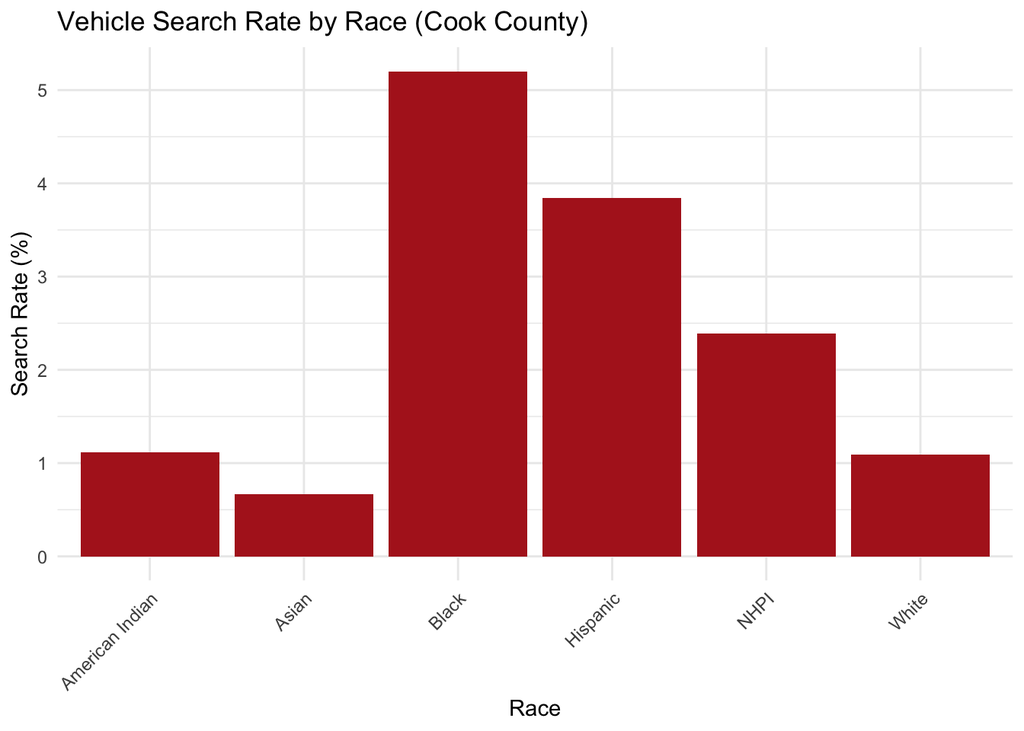

```r
ggplot(cook_search_rates, aes(x = race, y = search_rate)) +
  geom_col(fill = "#B22222") +
  labs(
    title = "Vehicle Search Rate by Race (Cook County)",
    x = "Race",
    y = "Search Rate (%)"
  ) +
  theme_minimal() +
  theme(axis.text.x = element_text(angle = 45, hjust = 1))
```

###### Top 3 Cook County Law Enforcment Agencies

- COOK COUNTY SHERIFF 56095
- SCHAUMBURG POLICE 23916
- PALATINE POLICE 19314

###### Cook County Sheriff

```r
cook_pop <- data.frame(
  race = c("White", "Black", "Hispanic", "Asian", "American Indian", "NHPI"),
  population_pct = c(61.2, 22.8, 27.8, 9.1, 3, 0.1)
)
```

```r
cook_sheriff <- cook_law |>
  filter(agency_name == "COOK COUNTY SHERIFF") |>
  count(race) |>
  mutate(stop_pct = n/sum(n) * 100)

cook_sheriff <- cook_sheriff|>
  left_join(cook_pop, by ="race")

cook_sheriff
```

```
##               race     n   stop_pct population_pct
##             <char> <int>      <num>          <num>
## 1: American Indian   465  0.8289509            3.0
## 2:           Asian  4110  7.3268562            9.1
## 3:           Black 16008 28.5373028           22.8
## 4:        Hispanic 16523 29.4553882           27.8
## 5:            NHPI   245  0.4367591            0.1
## 6:           White 18744 33.4147428           61.2
```

- Black and Hispanic drivers are overrepresented in traffic stops relative to their share of the population, while White and Asian drivers are underrepresented.

```r
## graphing it
cook_sheriff_plot <- cook_sheriff %>%
  select(race, stop_pct, population_pct) %>%
  pivot_longer(
    cols = c(stop_pct, population_pct),
    names_to = "type",
    values_to = "percent"
  )
```

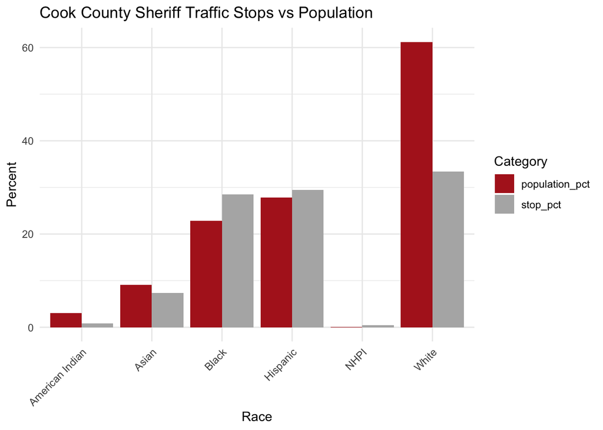

```r
## graphing it
ggplot(cook_sheriff_plot, aes(x = race, y = percent, fill = type)) +
  geom_col(position = "dodge") +
  scale_fill_manual(values = c(
    "stop_pct" = "grey70",
    "population_pct" = "#B22222"
  )) +
  labs(
    title = "Cook County Sheriff Traffic Stops vs Population",
    x = "Race",
    y = "Percent",
    fill = "Category"
  ) +
  theme_minimal() +
  theme(axis.text.x = element_text(angle = 45, hjust = 1))
```

```r
### creating a new data table that has the total number of stops by race and then getting the number of searches that was conducted, creating a rate by taking searches divided by total stops and multiplying by 100 to get a percentage
cook_sheriff_search_rates <- cook_law |>
  filter(agency_name == "COOK COUNTY SHERIFF") |>
  group_by(race) |>
  summarise(
    total_stops = n(),
    searches = sum(vehicle_search_conducted == "Yes", na.rm = TRUE),
    search_rate = searches/ total_stops * 100
  )

cook_sheriff_search_rates
```

```
## # A tibble: 6 × 4
##   race            total_stops searches search_rate
##   <chr>                 <int>    <int>       <dbl>
## 1 American Indian         465       10       2.15
## 2 Asian                  4110       41       0.998
## 3 Black                 16008     2244      14.0
## 4 Hispanic              16523      749       4.53
## 5 NHPI                    245       15       6.12
## 6 White                 18744      197       1.05
```

- Black drivers have the highest search rate (14) followed by NHPI drivers (small numbers 6.1), and then Hispanic drivers (4.5) and then American Indian (small numbers 2.2), and then White (1.1)

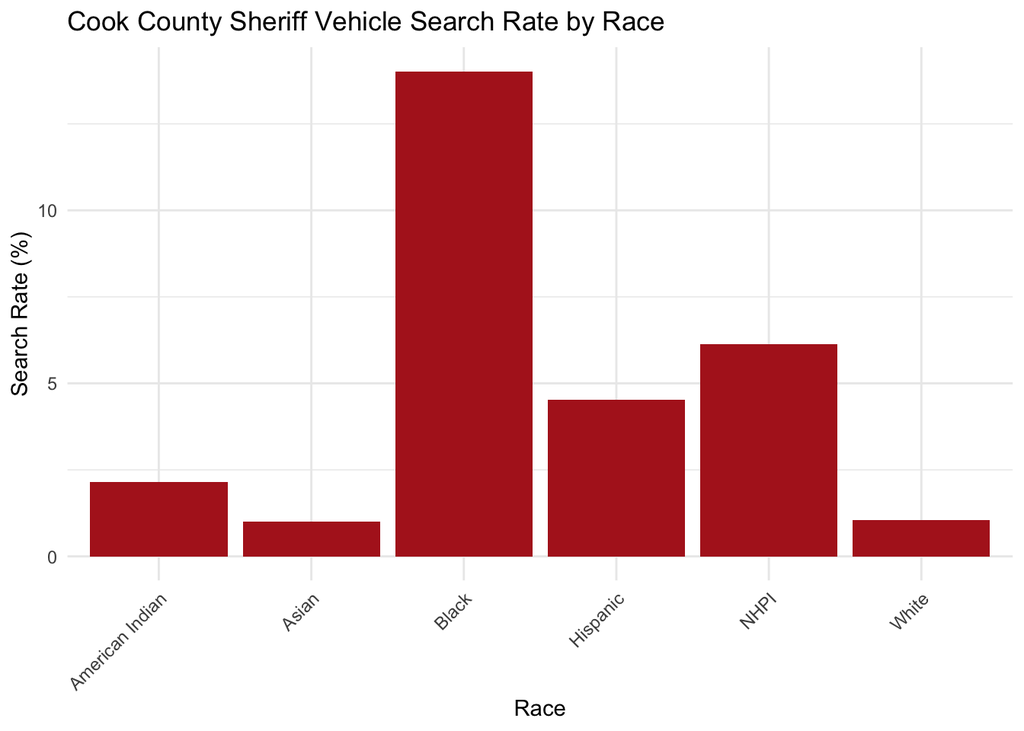

```r
ggplot(cook_sheriff_search_rates, aes(x = race, y = search_rate)) +
  geom_col(fill = "#B22222") +
  labs(
    title = "Cook County Sheriff Vehicle Search Rate by Race",
    x = "Race",
    y = "Search Rate (%)"
  ) +
  theme_minimal() +
  theme(axis.text.x = element_text(angle = 45, hjust = 1))
```

###### Schaumburg Police

```r
schaumburg_pop <- data.frame(
  race = c("White", "Black", "Hispanic", "Asian", "American Indian", "NHPI"),
  population_pct = c(53.7, 5.8, 12.7, 23.9, 0.5, 0)
)
```

```r
schaumburg_police_cook <- cook_law |>
  filter(agency_name == "SCHAUMBURG POLICE") |>
  count(race) |>
  mutate(stop_pct = n/sum(n) * 100)

schaumburg_police_cook <- schaumburg_police_cook |>
  left_join(schaumburg_pop, by ="race")

schaumburg_police_cook
```

```
##               race     n   stop_pct population_pct
##             <char> <int>      <num>          <num>
## 1: American Indian   156  0.6522830            0.5
## 2:           Asian  4069 17.0137147           23.9
## 3:           Black  2524 10.5536043            5.8
## 4:        Hispanic  6336 26.4927245           12.7
## 5:            NHPI   108  0.4515805            0.0
## 6:           White 10723 44.8360930           53.7
```

```r
schaumburg_police_cook_search_rates <- cook_law |>
  filter(agency_name == "SCHAUMBURG POLICE") |>
  group_by(race) |>
  summarise(
    total_stops = n(),
    searches = sum(vehicle_search_conducted == "Yes", na.rm = TRUE),
    search_rate = searches/ total_stops * 100
  )

schaumburg_police_cook_search_rates
```

```
## # A tibble: 6 × 4
##   race            total_stops searches search_rate
##   <chr>                 <int>    <int>       <dbl>
## 1 American Indian         156        1       0.641
## 2 Asian                  4069        7       0.172
## 3 Black                  2524       42       1.66
## 4 Hispanic               6336       61       0.963
## 5 NHPI                    108        1       0.926
## 6 White                 10723       31       0.289
```

###### Palatine Police

```r
palatine_pop <- data.frame(
  race = c("White", "Black", "Hispanic", "Asian", "American Indian", "NHPI"),
  population_pct = c(60.7, 4.6, 19.2, 12.7, 0.7, 0.4)
)
```

```r
palatine_police <- cook_law |>
  filter(agency_name == "PALATINE POLICE") |>
  count(race) |>
  mutate(stop_pct = n/sum(n) * 100)

palatine_police <- palatine_police |>
  left_join(palatine_pop, by ="race")

palatine_police
```

```
##               race     n   stop_pct population_pct
##             <char> <int>      <num>          <num>
## 1: American Indian    77  0.3986745            0.7
## 2:           Asian  1701  8.8070829           12.7
## 3:           Black  1394  7.2175624            4.6
## 4:        Hispanic  5323 27.5603189           19.2
## 5:            NHPI    54  0.2795899            0.4
## 6:           White 10765 55.7367713           60.7
```

```r
palatine_police_search_rates <- cook_law |>
  filter(agency_name == "PALATINE POLICE") |>
  group_by(race) |>
  summarise(
    total_stops = n(),
    searches = sum(vehicle_search_conducted == "Yes", na.rm = TRUE),
    search_rate = searches/ total_stops * 100
  )

palatine_police_search_rates
```

```
## # A tibble: 6 × 4
##   race            total_stops searches search_rate
##   <chr>                 <int>    <int>       <dbl>
## 1 American Indian          77        0       0
## 2 Asian                  1701        9       0.529
## 3 Black                  1394       61       4.38
## 4 Hispanic               5323      241       4.53
## 5 NHPI                     54        1       1.85
## 6 White                 10765      105       0.975
```

###### Wheeling Police

```r
wheeling_pop <- data.frame(
  race = c("White", "Black", "Hispanic", "Asian", "American Indian", "NHPI"),
  population_pct = c(49.1, 4, 28.1, 15.9, 1.2, 0)
)
```

```r
wheeling_police <- cook_law |>
  filter(agency_name == "WHEELING POLICE") |>
  count(race) |>
  mutate(stop_pct = n/sum(n) * 100)

wheeling_police <- wheeling_police |>
  left_join(wheeling_pop, by ="race")

wheeling_police
```

```
##               race     n   stop_pct population_pct
##             <char> <int>      <num>          <num>
## 1: American Indian    76  0.4576108            1.2
## 2:           Asian  1644  9.8988439           15.9
## 3:           Black  1042  6.2740848            4.0
## 4:        Hispanic  2924 17.6059730           28.1
## 5:            NHPI    78  0.4696532            0.0
## 6:           White 10844 65.2938343           49.1
```

```r
wheeling_police_search_rates <- cook_law |>
  filter(agency_name == "WHEELING POLICE") |>
  group_by(race) |>
  summarise(
    total_stops = n(),
    searches = sum(vehicle_search_conducted == "Yes", na.rm = TRUE),
    search_rate = searches/ total_stops * 100
  )

wheeling_police_search_rates
```

```
## # A tibble: 6 × 4
##   race            total_stops searches search_rate
##   <chr>                 <int>    <int>       <dbl>
## 1 American Indian          76        0       0
## 2 Asian                  1644        0       0
## 3 Black                  1042        5       0.480
## 4 Hispanic               2924       21       0.718
## 5 NHPI                     78        0       0
## 6 White                 10844       41       0.378
```

###### Evergreen Park Police

```r
evergreenpark_pop <- data.frame(
  race = c("White", "Black", "Hispanic", "Asian", "American Indian", "NHPI"),
  population_pct = c(49.8, 25.6, 17.6, 2.5, 0.6, 0)
)
```

```r
evergreenpark__police <- cook_law |>
  filter(agency_name == "EVERGREEN PARK POLICE") |>
  count(race) |>
  mutate(stop_pct = n/sum(n) * 100)

evergreenpark__police <- evergreenpark__police |>
  left_join(evergreenpark_pop, by ="race")

evergreenpark__police
```

```
##               race     n    stop_pct population_pct
##             <char> <int>       <num>          <num>
## 1: American Indian    38  0.27598228            0.6
## 2:           Asian    82  0.59554071            2.5
## 3:           Black  8056 58.50824315           25.6
## 4:        Hispanic  1238  8.99121214           17.6
## 5:            NHPI     6  0.04357615            0.0
## 6:           White  4349 31.58544557           49.8
```

```r
evergreenpark_police_search_rates <- cook_law |>
  filter(agency_name == "EVERGREEN PARK POLICE") |>
  group_by(race) |>
  summarise(
    total_stops = n(),
    searches = sum(vehicle_search_conducted == "Yes", na.rm = TRUE),
    search_rate = searches/ total_stops * 100
  )

evergreenpark_police_search_rates
```

```
## # A tibble: 6 × 4
##   race            total_stops searches search_rate
##   <chr>                 <int>    <int>       <dbl>
## 1 American Indian          38        1       2.63
## 2 Asian                    82        0       0
## 3 Black                  8056      133       1.65
## 4 Hispanic               1238       14       1.13
## 5 NHPI                      6        0       0
## 6 White                  4349       40       0.920
```

###### Oak Lawn Police

```r
oaklawn_pop <- data.frame(
  race = c("White", "Black", "Hispanic", "Asian", "American Indian", "NHPI"),
  population_pct = c(63.1, 8.9, 24, 1.7, 0.5, 0)
)
```

```r
oaklawn_police <- cook_law |>
  filter(agency_name == "OAK LAWN POLICE") |>
  count(race) |>
  mutate(stop_pct = n/sum(n) * 100)

oaklawn_police <- oaklawn_police |>
  left_join(oaklawn_pop, by ="race")

oaklawn_police
```

```
##               race     n    stop_pct population_pct
##             <char> <int>       <num>          <num>
## 1: American Indian    12  0.09269988            0.5
## 2:           Asian   157  1.21282348            1.7
## 3:           Black  4462 34.46890691            8.9
## 4:        Hispanic  1302 10.05793743           24.0
## 5:            NHPI     7  0.05407493            0.0
## 6:           White  7005 54.11355736           63.1
```

```r
oaklawn_police_search_rates <- cook_law |>
  filter(agency_name == "OAK LAWN POLICE") |>
  group_by(race) |>
  summarise(
    total_stops = n(),
    searches = sum(vehicle_search_conducted == "Yes", na.rm = TRUE),
    search_rate = searches/ total_stops * 100
  )

oaklawn_police_search_rates
```

```
## # A tibble: 6 × 4
##   race            total_stops searches search_rate
##   <chr>                 <int>    <int>       <dbl>
## 1 American Indian          12        1        8.33
## 2 Asian                   157        0        0
## 3 Black                  4462      136        3.05
## 4 Hispanic               1302       20        1.54
## 5 NHPI                      7        0        0
## 6 White                  7005       93        1.33
```

###### Mount Prospect Police

```r
mountprospect_pop <- data.frame(
  race = c("White", "Black", "Hispanic", "Asian", "American Indian", "NHPI"),
  population_pct = c(61, 2.5, 18.1, 15.5, 0.4, 0)
)
```

```r
mountprospect_police <- cook_law |>
  filter(agency_name == "MOUNT PROSPECT POLICE") |>
  count(race) |>
  mutate(stop_pct = n/sum(n) * 100)

mountprospect_police <- mountprospect_police |>
  left_join(mountprospect_pop, by ="race")

mountprospect_police
```

```
##        race     n  stop_pct population_pct
##      <char> <int>     <num>          <num>
## 1:    Asian  1955 15.950069           15.5
## 2:    Black   927  7.563025            2.5
## 3: Hispanic  3196 26.074896           18.1
## 4:    White  6179 50.412009           61.0
```

```r
mountprospect_police_search_rates <- cook_law |>
  filter(agency_name == "MOUNT PROSPECT POLICE") |>
  group_by(race) |>
  summarise(
    total_stops = n(),
    searches = sum(vehicle_search_conducted == "Yes", na.rm = TRUE),
    search_rate = searches/ total_stops * 100
  )

mountprospect_police_search_rates
```

```
## # A tibble: 4 × 4
##   race     total_stops searches search_rate
##   <chr>          <int>    <int>       <dbl>
## 1 Asian           1955       15       0.767
## 2 Black            927       54       5.83
## 3 Hispanic        3196      153       4.79
## 4 White           6179       65       1.05
```

###### Elk Grove Village Police

```r
elkgrove_pop <- data.frame(
  race = c("White", "Black", "Hispanic", "Asian", "American Indian", "NHPI"),
  population_pct = c(67.9, 3, 14.9, 12.1, 0.4, 0)
)
```

```r
elkgrove_police <- cook_law |>
  filter(agency_name == "ELK GROVE VILLAGE POLICE") |>
  count(race) |>
  mutate(stop_pct = n/sum(n) * 100)

elkgrove_police <- elkgrove_police |>
  left_join(elkgrove_pop, by ="race")

elkgrove_police
```

```
##               race     n   stop_pct population_pct
##             <char> <int>      <num>          <num>
## 1: American Indian    22  0.2082347            0.4
## 2:           Asian  1204 11.3961193           12.1
## 3:           Black  1052  9.9574065            3.0
## 4:        Hispanic  3050 28.8689068           14.9
## 5:            NHPI    41  0.3880738            0.0
## 6:           White  5196 49.1812589           67.9
```

```r
elkgrove_police_search_rates <- cook_law |>
  filter(agency_name == "ELK GROVE VILLAGE POLICE") |>
  group_by(race) |>
  summarise(
    total_stops = n(),
    searches = sum(vehicle_search_conducted == "Yes", na.rm = TRUE),
    search_rate = searches/ total_stops * 100
  )

elkgrove_police_search_rates
```

```
## # A tibble: 6 × 4
##   race            total_stops searches search_rate
##   <chr>                 <int>    <int>       <dbl>
## 1 American Indian          22        0       0
## 2 Asian                  1204        4       0.332
## 3 Black                  1052       31       2.95
## 4 Hispanic               3050       60       1.97
## 5 NHPI                     41        0       0
## 6 White                  5196       18       0.346
```

###### Alsip Police

```r
alsip_pop <- data.frame(
  race = c("White", "Black", "Hispanic", "Asian", "American Indian", "NHPI"),
  population_pct = c(40, 24.3, 28.6, 2.3, 1.5, 0)
)
```

```r
alsip_police <- cook_law |>
  filter(agency_name == "ALSIP POLICE") |>
  count(race) |>
  mutate(stop_pct = n/sum(n) * 100)

alsip_police <- alsip_police |>
  left_join(alsip_pop, by ="race")

alsip_police
```

```
##               race     n     stop_pct population_pct
##             <char> <int>        <num>          <num>
## 1: American Indian     6  0.059119125            1.5
## 2:           Asian    32  0.315302000            2.3
## 3:           Black  4074 40.141885900           24.3
## 4:        Hispanic   809  7.971228692           28.6
## 5:            NHPI     1  0.009853188            0.0
## 6:           White  5227 51.502611095           40.0
```

```r
alsip_police_search_rates <- cook_law |>
  filter(agency_name == "ALSIP POLICE") |>
  group_by(race) |>
  summarise(
    total_stops = n(),
    searches = sum(vehicle_search_conducted == "Yes", na.rm = TRUE),
    search_rate = searches/ total_stops * 100
  )

alsip_police_search_rates
```

```
## # A tibble: 6 × 4
##   race            total_stops searches search_rate
##   <chr>                 <int>    <int>       <dbl>
## 1 American Indian           6        0       0
## 2 Asian                    32        0       0
## 3 Black                  4074       14       0.344
## 4 Hispanic                809       11       1.36
## 5 NHPI                      1        0       0
## 6 White                  5227        7       0.134
```

###### Buffalo Grove Police

```r
buffalo_pop <- data.frame(
  race = c("White", "Black", "Hispanic", "Asian", "American Indian", "NHPI"),
  population_pct = c(58.2, 3.4, 5.8, 29.8, 0.5, 0.1)
)
```

```r
buffalo_police_cook <- cook_law |>
  filter(agency_name == "BUFFALO GROVE POLICE") |>
  count(race) |>
  mutate(stop_pct = n/sum(n) * 100)

buffalo_police_cook <- buffalo_police_cook |>
  left_join(buffalo_pop, by ="race")

buffalo_police_cook
```

```
##               race     n   stop_pct population_pct
##             <char> <int>      <num>          <num>
## 1: American Indian    17  0.1977664            0.5
## 2:           Asian  1199 13.9483481           29.8
## 3:           Black   606  7.0497906            3.4
## 4:        Hispanic  2064 24.0111680            5.8
## 5:            NHPI    18  0.2093997            0.1
## 6:           White  4692 54.5835272           58.2
```

```r
buffalo_cook_police_search_rates <- cook_law |>
  filter(agency_name == "BUFFALO GROVE POLICE") |>
  group_by(race) |>
  summarise(
    total_stops = n(),
    searches = sum(vehicle_search_conducted == "Yes", na.rm = TRUE),
    search_rate = searches/ total_stops * 100
  )

buffalo_cook_police_search_rates
```

```
## # A tibble: 6 × 4
##   race            total_stops searches search_rate
##   <chr>                 <int>    <int>       <dbl>
## 1 American Indian          17        0       0
## 2 Asian                  1199        2       0.167
## 3 Black                   606        9       1.49
## 4 Hispanic               2064       24       1.16
## 5 NHPI                     18        0       0
## 6 White                  4692       12       0.256
```

##### Hoffman Estates Police

```r
hoffmanestates_pop <- data.frame(
  race = c("White", "Black", "Hispanic", "Asian", "American Indian", "NHPI"),
  population_pct = c(47.9, 6.1, 17, 25.2, 0.4, 0)
)
```

```r
hoffmanestates_police <- cook_law |>
  filter(agency_name == "HOFFMAN ESTATES POLICE") |>
  count(race) |>
  mutate(stop_pct = n/sum(n) * 100)

hoffmanestates_police <- hoffmanestates_police |>
  left_join(hoffmanestates_pop, by ="race")

hoffmanestates_police
```

```
##               race     n   stop_pct population_pct
##             <char> <int>      <num>          <num>
## 1: American Indian    53  0.6613427            0.4
## 2:           Asian  1662 20.7387073           25.2
## 3:           Black   910 11.3551285            6.1
## 4:        Hispanic  2398 29.9226354           17.0
## 5:            NHPI    33  0.4117794            0.0
## 6:           White  2958 36.9104068           47.9
```

```r
hoffmanestates_police_search_rates <- cook_law |>
  filter(agency_name == "HOFFMAN ESTATES POLICE") |>
  group_by(race) |>
  summarise(
    total_stops = n(),
    searches = sum(vehicle_search_conducted == "Yes", na.rm = TRUE),
    search_rate = searches/ total_stops * 100
  )

hoffmanestates_police_search_rates
```

```
## # A tibble: 6 × 4
##   race            total_stops searches search_rate
##   <chr>                 <int>    <int>       <dbl>
## 1 American Indian          53        0       0
## 2 Asian                  1662       15       0.903
## 3 Black                   910       35       3.85
## 4 Hispanic               2398       89       3.71
## 5 NHPI                     33        2       6.06
## 6 White                  2958       56       1.89
```

###### Berwyn Police

```r
berwyn_pop <- data.frame(
  race = c("White", "Black", "Hispanic", "Asian", "American Indian", "NHPI"),
  population_pct = c(24.9, 7.7, 62.8, 3.9, 3.1, 0)
)
```

```r
berwyn_police <- cook_law |>
  filter(agency_name == "BERWYN POLICE") |>
  count(race) |>
  mutate(stop_pct = n/sum(n) * 100)

berwyn_police <- berwyn_police |>
  left_join(berwyn_pop, by ="race")

berwyn_police
```

```
##        race     n  stop_pct population_pct
##      <char> <int>     <num>          <num>
## 1:    Asian    94  1.180015            3.9
## 2:    Black  1211 15.202109            7.7
## 3: Hispanic  5439 68.277680           62.8
## 4:    White  1222 15.340196           24.9
```

```r
berwyn_police_search_rates <- cook_law |>
  filter(agency_name == "BERWYN POLICE") |>
  group_by(race) |>
  summarise(
    total_stops = n(),
    searches = sum(vehicle_search_conducted == "Yes", na.rm = TRUE),
    search_rate = searches/ total_stops * 100
  )

berwyn_police_search_rates
```

```
## # A tibble: 4 × 4
##   race     total_stops searches search_rate
##   <chr>          <int>    <int>       <dbl>
## 1 Asian             94        3       3.19
## 2 Black           1211       64       5.28
## 3 Hispanic        5439      143       2.63
## 4 White           1222       10       0.818
```

##### Blue Island Police

```r
blueisland_pop <- data.frame(
  race = c("White", "Black", "Hispanic", "Asian", "American Indian", "NHPI"),
  population_pct = c(18, 30.8, 47.5, 0.8, 0.3, 0.3)
)
```

```r
blueisland_police <- cook_law |>
  filter(agency_name == "BLUE ISLAND POLICE") |>
  count(race) |>
  mutate(stop_pct = n/sum(n) * 100)

blueisland_police <- blueisland_police |>
  left_join(blueisland_pop, by ="race")

blueisland_police
```

```
##               race     n   stop_pct population_pct
##             <char> <int>      <num>          <num>
## 1: American Indian    25  0.3374730            0.3
## 2:           Asian    28  0.3779698            0.8
## 3:           Black  4492 60.6371490           30.8
## 4:        Hispanic  1982 26.7548596           47.5
## 5:            NHPI    29  0.3914687            0.3
## 6:           White   852 11.5010799           18.0
```

```r
blueisland_police_search_rates <- cook_law |>
  filter(agency_name == "BLUE ISLAND POLICE") |>
  group_by(race) |>
  summarise(
    total_stops = n(),
    searches = sum(vehicle_search_conducted == "Yes", na.rm = TRUE),
    search_rate = searches/ total_stops * 100
  )

blueisland_police_search_rates
```

```
## # A tibble: 6 × 4
##   race            total_stops searches search_rate
##   <chr>                 <int>    <int>       <dbl>
## 1 American Indian          25        0        0
## 2 Asian                    28        0        0
## 3 Black                  4492      157        3.50
## 4 Hispanic               1982       72        3.63
## 5 NHPI                     29        0        0
## 6 White                   852       10        1.17
```

###### Orland Park Police

```r
orlandpark_pop <- data.frame(
  race = c("White", "Black", "Hispanic", "Asian", "American Indian", "NHPI"),
  population_pct = c(77.3, 4, 10.7, 6.2, 0.2, 0.2)
)
```

```r
orlandpark_police <- cook_law |>
  filter(agency_name == "ORLAND PARK POLICE") |>
  count(race) |>
  mutate(stop_pct = n/sum(n) * 100)

orlandpark_police <- orlandpark_police |>
  left_join(orlandpark_pop, by ="race")

orlandpark_police
```

```
##               race     n   stop_pct population_pct
##             <char> <int>      <num>          <num>
## 1: American Indian     1  0.0137817            0.2
## 2:           Asian    53  0.7304300            6.2
## 3:           Black  1558 21.4718853            4.0
## 4:        Hispanic   809 11.1493936           10.7
## 5:            NHPI    11  0.1515987            0.2
## 6:           White  4824 66.4829107           77.3
```

```r
orlandpark_police_search_rates <- cook_law |>
  filter(agency_name == "ORLAND PARK POLICE") |>
  group_by(race) |>
  summarise(
    total_stops = n(),
    searches = sum(vehicle_search_conducted == "Yes", na.rm = TRUE),
    search_rate = searches/ total_stops * 100
  )

orlandpark_police_search_rates
```

```
## # A tibble: 6 × 4
##   race            total_stops searches search_rate
##   <chr>                 <int>    <int>       <dbl>
## 1 American Indian           1        0        0
## 2 Asian                    53        0        0
## 3 Black                  1558      162       10.4
## 4 Hispanic                809       32        3.96
## 5 NHPI                     11        0        0
## 6 White                  4824       91        1.89
```

###### Lansing Police

```r
lansing_pop <- data.frame(
  race = c("White", "Black", "Hispanic", "Asian", "American Indian", "NHPI"),
  population_pct = c(25.2, 51.9, 17.9, 2.2, 0.8, 0.1)
)
```

```r
lansing_police <- cook_law |>
  filter(agency_name == "LANSING POLICE") |>
  count(race) |>
  mutate(stop_pct = n/sum(n) * 100)

lansing_police <- lansing_police |>
  left_join(lansing_pop, by ="race")

lansing_police
```

```
##               race     n   stop_pct population_pct
##             <char> <int>      <num>          <num>
## 1: American Indian    16  0.2239955            0.8
## 2:           Asian    44  0.6159877            2.2
## 3:           Black  5396 75.5424892           51.9
## 4:        Hispanic   889 12.4457511           17.9
## 5:            NHPI    82  1.1479770            0.1
## 6:           White   716 10.0237995           25.2
```

```r
lansing_police_search_rates <- cook_law |>
  filter(agency_name == "LANSING POLICE") |>
  group_by(race) |>
  summarise(
    total_stops = n(),
    searches = sum(vehicle_search_conducted == "Yes", na.rm = TRUE),
    search_rate = searches/ total_stops * 100
  )

lansing_police_search_rates
```

```
## # A tibble: 6 × 4
##   race            total_stops searches search_rate
##   <chr>                 <int>    <int>       <dbl>
## 1 American Indian          16        0       0
## 2 Asian                    44        1       2.27
## 3 Black                  5396       69       1.28
## 4 Hispanic                889        6       0.675
## 5 NHPI                     82        0       0
## 6 White                   716        7       0.978
```

###### Bellwood Police

```r
bellwood_pop <- data.frame(
  race = c("White", "Black", "Hispanic", "Asian", "American Indian", "NHPI"),
  population_pct = c(2.6, 69.5, 27, 1, 0.5, 0)
)
```

```r
bellwood_police <- cook_law |>
  filter(agency_name == "BELLWOOD POLICE") |>
  count(race) |>
  mutate(stop_pct = n/sum(n) * 100)

bellwood_police <- bellwood_police |>
  left_join(bellwood_pop, by ="race")

bellwood_police
```

```
##               race     n    stop_pct population_pct
##             <char> <int>       <num>          <num>
## 1: American Indian    10  0.14084507            0.5
## 2:           Asian    87  1.22535211            1.0
## 3:           Black  4031 56.77464789           69.5
## 4:        Hispanic  1561 21.98591549           27.0
## 5:            NHPI     1  0.01408451            0.0
## 6:           White  1410 19.85915493            2.6
```

```r
bellwood_police_search_rates <- cook_law |>
  filter(agency_name == "BELLWOOD POLICE") |>
  group_by(race) |>
  summarise(
    total_stops = n(),
    searches = sum(vehicle_search_conducted == "Yes", na.rm = TRUE),
    search_rate = searches/ total_stops * 100
  )

bellwood_police_search_rates
```

```
## # A tibble: 6 × 4
##   race            total_stops searches search_rate
##   <chr>                 <int>    <int>       <dbl>
## 1 American Indian          10        1      10
## 2 Asian                    87        1       1.15
## 3 Black                  4031      111       2.75
## 4 Hispanic               1561       27       1.73
## 5 NHPI                      1        0       0
## 6 White                  1410        5       0.355
```

###### Skokie Police

```r
skokie_pop <- data.frame(
  race = c("White", "Black", "Hispanic", "Asian", "American Indian", "NHPI"),
  population_pct = c(48.6, 10.1, 11, 25.4, 0.3, 0)
)
```

```r
skokie_police <- cook_law |>
  filter(agency_name == "SKOKIE POLICE") |>
  count(race) |>
  mutate(stop_pct = n/sum(n) * 100)

skokie_police <- skokie_police |>
  left_join(skokie_pop, by ="race")

skokie_police
```

```
##               race     n    stop_pct population_pct
##             <char> <int>       <num>          <num>
## 1: American Indian   581  9.01474011            0.3
## 2:           Asian   866 13.43677269           25.4
## 3:           Black  1150 17.84328937           10.1
## 4:        Hispanic   530  8.22342901           11.0
## 5:            NHPI     5  0.07757952            0.0
## 6:           White  3313 51.40418929           48.6
```

```r
skokie_police_search_rates <- cook_law |>
  filter(agency_name == "SKOKIE POLICE") |>
  group_by(race) |>
  summarise(
    total_stops = n(),
    searches = sum(vehicle_search_conducted == "Yes", na.rm = TRUE),
    search_rate = searches/ total_stops * 100
  )

skokie_police_search_rates
```

```
## # A tibble: 6 × 4
##   race            total_stops searches search_rate
##   <chr>                 <int>    <int>       <dbl>
## 1 American Indian         581        1       0.172
## 2 Asian                   866        4       0.462
## 3 Black                  1150       45       3.91
## 4 Hispanic                530       12       2.26
## 5 NHPI                      5        0       0
## 6 White                  3313       20       0.604
```

###### Calumet City Police

```r
calumetcity_pop <- data.frame(
  race = c("White", "Black", "Hispanic", "Asian", "American Indian", "NHPI"),
  population_pct = c(5.6, 75.2, 16.3, 0.2, 0.1, 0.2)
)
```

```r
calumetcity_police <- cook_law |>
  filter(agency_name == "CALUMET CITY POLICE") |>
  count(race) |>
  mutate(stop_pct = n/sum(n) * 100)

calumetcity_police <- calumetcity_police |>
  left_join(calumetcity_pop, by ="race")

calumetcity_police
```

```
##               race     n    stop_pct population_pct
##             <char> <int>       <num>          <num>
## 1: American Indian     6  0.09353079            0.1
## 2:           Asian    28  0.43647701            0.2
## 3:           Black  5230 81.52766952           75.2
## 4:        Hispanic   834 13.00077942           16.3
## 5:            NHPI    31  0.48324240            0.2
## 6:           White   286  4.45830086            5.6
```

```r
calumetcity_police_search_rates <- cook_law |>
  filter(agency_name == "CALUMET CITY POLICE") |>
  group_by(race) |>
  summarise(
    total_stops = n(),
    searches = sum(vehicle_search_conducted == "Yes", na.rm = TRUE),
    search_rate = searches/ total_stops * 100
  )

calumetcity_police_search_rates
```

```
## # A tibble: 6 × 4
##   race            total_stops searches search_rate
##   <chr>                 <int>    <int>       <dbl>
## 1 American Indian           6        0       0
## 2 Asian                    28        0       0
## 3 Black                  5230       42       0.803
## 4 Hispanic                834        5       0.600
## 5 NHPI                     31        0       0
## 6 White                   286        2       0.699
```

###### Arlington Heights Police

```r
arligtonheights_pop <- data.frame(
  race = c("White", "Black", "Hispanic", "Asian", "American Indian", "NHPI"),
  population_pct = c(75, 2.4, 8.5, 10.4, 0.2, 0)
)
```

```r
arligtonheights_police <- cook_law |>
  filter(agency_name == "ARLINGTON HEIGHTS POLICE") |>
  count(race) |>
  mutate(stop_pct = n/sum(n) * 100)

arligtonheights_police <- arligtonheights_police |>
  left_join(arligtonheights_pop, by ="race")

arligtonheights_police
```

```
##               race     n   stop_pct population_pct
##             <char> <int>      <num>          <num>
## 1: American Indian    23  0.3659507            0.2
## 2:           Asian   517  8.2259348           10.4
## 3:           Black   452  7.1917263            2.4
## 4:        Hispanic  1149 18.2816229            8.5
## 5:            NHPI    92  1.4638027            0.0
## 6:           White  4052 64.4709626           75.0
```

```r
arligtonheights_police_search_rates <- cook_law |>
  filter(agency_name == "ARLINGTON HEIGHTS POLICE") |>
  group_by(race) |>
  summarise(
    total_stops = n(),
    searches = sum(vehicle_search_conducted == "Yes", na.rm = TRUE),
    search_rate = searches/ total_stops * 100
  )

arligtonheights_police_search_rates
```

```
## # A tibble: 6 × 4
##   race            total_stops searches search_rate
##   <chr>                 <int>    <int>       <dbl>
## 1 American Indian          23        0       0
## 2 Asian                   517        0       0
## 3 Black                   452       12       2.65
## 4 Hispanic               1149        8       0.696
## 5 NHPI                     92        3       3.26
## 6 White                  4052       16       0.395
```

###### Franklin Park Police

```r
franklinpark_pop <- data.frame(
  race = c("White", "Black", "Hispanic", "Asian", "American Indian", "NHPI"),
  population_pct = c(33.4, 0.8, 62.2, 2.3, 1.6, 0)
)
```

```r
franklinpark_police <- cook_law |>
  filter(agency_name == "FRANKLIN PARK POLICE") |>
  count(race) |>
  mutate(stop_pct = n/sum(n) * 100)

franklinpark_police <- franklinpark_police |>
  left_join(franklinpark_pop, by ="race")

franklinpark_police
```

```
##               race     n stop_pct population_pct
##             <char> <int>    <num>          <num>
## 1: American Indian    23    0.368            1.6
## 2:           Asian   276    4.416            2.3
## 3:           Black  1005   16.080            0.8
## 4:        Hispanic  2210   35.360           62.2
## 5:            NHPI     8    0.128            0.0
## 6:           White  2728   43.648           33.4
```

```r
franklinpark_police_search_rates <- cook_law |>
  filter(agency_name == "FRANKLIN PARK POLICE") |>
  group_by(race) |>
  summarise(
    total_stops = n(),
    searches = sum(vehicle_search_conducted == "Yes", na.rm = TRUE),
    search_rate = searches/ total_stops * 100
  )

franklinpark_police_search_rates
```

```
## # A tibble: 6 × 4
##   race            total_stops searches search_rate
##   <chr>                 <int>    <int>       <dbl>
## 1 American Indian          23        2        8.70
## 2 Asian                   276        7        2.54
## 3 Black                  1005      114       11.3
## 4 Hispanic               2210      241       10.9
## 5 NHPI                      8        0        0
## 6 White                  2728      112        4.11
```

##### South Holland Police

```r
southholland_pop <- data.frame(
  race = c("White", "Black", "Hispanic", "Asian", "American Indian", "NHPI"),
  population_pct = c(10.2, 75.1, 10.4, 1, 0, 0)
)
```

```r
southholland_police <- cook_law |>
  filter(agency_name == "SOUTH HOLLAND POLICE") |>
  count(race) |>
  mutate(stop_pct = n/sum(n) * 100)

southholland_police <- southholland_police |>
  left_join(southholland_pop, by ="race")

southholland_police
```

```
##               race     n   stop_pct population_pct
##             <char> <int>      <num>          <num>
## 1: American Indian    13  0.2106969            0.0
## 2:           Asian    30  0.4862237            1.0
## 3:           Black  5134 83.2090762           75.1
## 4:        Hispanic   623 10.0972447           10.4
## 5:            NHPI     7  0.1134522            0.0
## 6:           White   363  5.8833063           10.2
```

```r
southholland_police_search_rates <- cook_law |>
  filter(agency_name == "SOUTH HOLLAND POLICE") |>
  group_by(race) |>
  summarise(
    total_stops = n(),
    searches = sum(vehicle_search_conducted == "Yes", na.rm = TRUE),
    search_rate = searches/ total_stops * 100
  )

southholland_police_search_rates
```

```
## # A tibble: 6 × 4
##   race            total_stops searches search_rate
##   <chr>                 <int>    <int>       <dbl>
## 1 American Indian          13        0        0
## 2 Asian                    30        0        0
## 3 Black                  5134      310        6.04
## 4 Hispanic                623       14        2.25
## 5 NHPI                      7        0        0
## 6 White                   363        5        1.38
```

###### Homewood Police

```r
homewood_pop <- data.frame(
  race = c("White", "Black", "Hispanic", "Asian", "American Indian", "NHPI"),
  population_pct = c(44.3, 43.3, 6.4, 1.4, 0.4, 0.4)
)
```

```r
homewood_police <- cook_law |>
  filter(agency_name == "HOMEWOOD POLICE") |>
  count(race) |>
  mutate(stop_pct = n/sum(n) * 100)

homewood_police <- homewood_police |>
  left_join(homewood_pop, by ="race")

homewood_police
```

```
##               race     n    stop_pct population_pct
##             <char> <int>       <num>          <num>
## 1: American Indian    15  0.25641026            0.4
## 2:           Asian    23  0.39316239            1.4
## 3:           Black  4716 80.61538462           43.3
## 4:        Hispanic   481  8.22222222            6.4
## 5:            NHPI     5  0.08547009            0.4
## 6:           White   610 10.42735043           44.3
```

```r
homewood_police_search_rates <- cook_law |>
  filter(agency_name == "HOMEWOOD POLICE") |>
  group_by(race) |>
  summarise(
    total_stops = n(),
    searches = sum(vehicle_search_conducted == "Yes", na.rm = TRUE),
    search_rate = searches/ total_stops * 100
  )

homewood_police_search_rates
```

```
## # A tibble: 6 × 4
##   race            total_stops searches search_rate
##   <chr>                 <int>    <int>       <dbl>
## 1 American Indian          15        0       0
## 2 Asian                    23        0       0
## 3 Black                  4716       46       0.975
## 4 Hispanic                481       11       2.29
## 5 NHPI                      5        0       0
## 6 White                   610        7       1.15
```

###### Hometown Police

```r
hometown_pop <- data.frame(
  race = c("White", "Black", "Hispanic", "Asian", "American Indian", "NHPI"),
  population_pct = c(60.2, 0.64, 18.4, 0, 0, 0)
)
```

```r
hometown_police <- cook_law |>
  filter(agency_name == "HOMETOWN POLICE") |>
  count(race) |>
  mutate(stop_pct = n/sum(n) * 100)

hometown_police <- hometown_police |>
  left_join(hometown_pop, by ="race")

hometown_police
```

```
##               race     n   stop_pct population_pct
##             <char> <int>      <num>          <num>
## 1: American Indian    10  0.1768347           0.00
## 2:           Asian   168  2.9708223           0.00
## 3:           Black  2158 38.1609195           0.64
## 4:        Hispanic  1924 34.0229885          18.40
## 5:            NHPI    51  0.9018568           0.00
## 6:           White  1344 23.7665782          60.20
```

```r
hometown_police_search_rates <- cook_law |>
  filter(agency_name == "HOMETOWN POLICE") |>
  group_by(race) |>
  summarise(
    total_stops = n(),
    searches = sum(vehicle_search_conducted == "Yes", na.rm = TRUE),
    search_rate = searches/ total_stops * 100
  )

hometown_police_search_rates
```

```
## # A tibble: 6 × 4
##   race            total_stops searches search_rate
##   <chr>                 <int>    <int>       <dbl>
## 1 American Indian          10        1       10
## 2 Asian                   168       10        5.95
## 3 Black                  2158      140        6.49
## 4 Hispanic               1924       93        4.83
## 5 NHPI                     51        1        1.96
## 6 White                  1344       29        2.16
```

###### Evanston Police

```r
evanston_pop <- data.frame(
  race = c("White", "Black", "Hispanic", "Asian", "American Indian", "NHPI"),
  population_pct = c(58, 14.4, 12.3, 9.4, 0.4, 0)
)
```

```r
evanston_police <- cook_law |>
  filter(agency_name == "EVANSTON POLICE") |>
  count(race) |>
  mutate(stop_pct = n/sum(n) * 100)

evanston_police <- evanston_police |>
  left_join(evanston_pop, by ="race")

evanston_police
```

```
##               race     n    stop_pct population_pct
##             <char> <int>       <num>          <num>
## 1: American Indian    64  1.18255728            0.4
## 2:           Asian   542 10.01478197            9.4
## 3:           Black  1714 31.67036216           14.4
## 4:        Hispanic   569 10.51367332           12.3
## 5:            NHPI     5  0.09238729            0.0
## 6:           White  2518 46.52623799           58.0
```

```r
evanston_police_search_rates <- cook_law |>
  filter(agency_name == "EVANSTON POLICE") |>
  group_by(race) |>
  summarise(
    total_stops = n(),
    searches = sum(vehicle_search_conducted == "Yes", na.rm = TRUE),
    search_rate = searches/ total_stops * 100
  )

evanston_police_search_rates
```

```
## # A tibble: 6 × 4
##   race            total_stops searches search_rate
##   <chr>                 <int>    <int>       <dbl>
## 1 American Indian          64        1       1.56
## 2 Asian                   542        1       0.185
## 3 Black                  1714      130       7.58
## 4 Hispanic                569       13       2.28
## 5 NHPI                      5        0       0
## 6 White                  2518       16       0.635
```

###### Tinley Park Police

```r
tinleypark_pop <- data.frame(
  race = c("White", "Black", "Hispanic", "Asian", "American Indian", "NHPI"),
  population_pct = c(76.2, 6.7, 10.9, 3.7, 0, 0)
)
```

```r
tinleypark_police <- cook_law |>
  filter(agency_name == "TINLEY PARK POLICE") |>
  count(race) |>
  mutate(stop_pct = n/sum(n) * 100)

tinleypark_police <- tinleypark_police |>
  left_join(tinleypark_pop, by ="race")

tinleypark_police
```

```
##               race     n   stop_pct population_pct
##             <char> <int>      <num>          <num>
## 1: American Indian    10  0.1905125            0.0
## 2:           Asian    54  1.0287674            3.7
## 3:           Black  1784 33.9874262            6.7
## 4:        Hispanic   237  4.5151457           10.9
## 5:           White  3164 60.2781482           76.2
```

```r
tinleypark_police_search_rates <- cook_law |>
  filter(agency_name == "TINLEY PARK POLICE") |>
  group_by(race) |>
  summarise(
    total_stops = n(),
    searches = sum(vehicle_search_conducted == "Yes", na.rm = TRUE),
    search_rate = searches/ total_stops * 100
  )

tinleypark_police_search_rates
```

```
## # A tibble: 5 × 4
##   race            total_stops searches search_rate
##   <chr>                 <int>    <int>       <dbl>
## 1 American Indian          10        0        0
## 2 Asian                    54        0        0
## 3 Black                  1784       55        3.08
## 4 Hispanic                237        5        2.11
## 5 White                  3164       46        1.45
```

###### Oak Park Police

```r
oakpark_pop <- data.frame(
  race = c("White", "Black", "Hispanic", "Asian", "American Indian", "NHPI"),
  population_pct = c(61.5, 17.9, 9.3, 5.4, 0.5, 0)
)
```

```r
oakpark_police <- cook_law |>
  filter(agency_name == "OAK PARK POLICE") |>
  count(race) |>
  mutate(stop_pct = n/sum(n) * 100)

oakpark_police <- oakpark_police |>
  left_join(oakpark_pop, by ="race")

oakpark_police
```

```
##               race     n   stop_pct population_pct
##             <char> <int>      <num>          <num>
## 1: American Indian    20  0.3891051            0.5
## 2:           Asian   112  2.1789883            5.4
## 3:           Black  2499 48.6186770           17.9
## 4:        Hispanic   665 12.9377432            9.3
## 5:            NHPI    22  0.4280156            0.0
## 6:           White  1822 35.4474708           61.5
```

```r
oakpark_police_search_rates <- cook_law |>
  filter(agency_name == "OAK PARK POLICE") |>
  group_by(race) |>
  summarise(
    total_stops = n(),
    searches = sum(vehicle_search_conducted == "Yes", na.rm = TRUE),
    search_rate = searches/ total_stops * 100
  )

oakpark_police_search_rates
```

```
## # A tibble: 6 × 4
##   race            total_stops searches search_rate
##   <chr>                 <int>    <int>       <dbl>
## 1 American Indian          20        0       0
## 2 Asian                   112        1       0.893
## 3 Black                  2499       76       3.04
## 4 Hispanic                665        8       1.20
## 5 NHPI                     22        1       4.55
## 6 White                  1822        9       0.494
```

###### Westmont Police

```r
westmont_pop <- data.frame(
  race = c("White", "Black", "Hispanic", "Asian", "American Indian", "NHPI"),
  population_pct = c(61.7, 5.9, 14.2, 14.9, 1.1, 0)
)
```

```r
westmont_police <- cook_law |>
  filter(agency_name == "WESTMONT POLICE") |>
  count(race) |>
  mutate(stop_pct = n/sum(n) * 100)

westmont_police <- westmont_police |>
  left_join(westmont_pop, by ="race")

westmont_police
```

```
##               race     n   stop_pct population_pct
##             <char> <int>      <num>          <num>
## 1: American Indian    15  0.2980330            1.1
## 2:           Asian   284  5.6427578           14.9
## 3:           Black   781 15.5175839            5.9
## 4:        Hispanic   792 15.7361415           14.2
## 5:            NHPI     3  0.0596066            0.0
## 6:           White  3158 62.7458772           61.7
```

```r
westmont_police_search_rates <- cook_law |>
  filter(agency_name == "WESTMONT POLICE") |>
  group_by(race) |>
  summarise(
    total_stops = n(),
    searches = sum(vehicle_search_conducted == "Yes", na.rm = TRUE),
    search_rate = searches/ total_stops * 100
  )

westmont_police_search_rates
```

```
## # A tibble: 6 × 4
##   race            total_stops searches search_rate
##   <chr>                 <int>    <int>       <dbl>
## 1 American Indian          15        0       0
## 2 Asian                   284        0       0
## 3 Black                   781        6       0.768
## 4 Hispanic                792        9       1.14
## 5 NHPI                      3        0       0
## 6 White                  3158       13       0.412
```

###### Wilmette Police

```r
wilmette_pop <- data.frame(
  race = c("White", "Black", "Hispanic", "Asian", "American Indian", "NHPI"),
  population_pct = c(76.3, 1, 4.9, 12.3, 0, 0)
)
```

```r
wilmette_police <- cook_law |>
  filter(agency_name == "WILMETTE POLICE") |>
  count(race) |>
  mutate(stop_pct = n/sum(n) * 100)

wilmette_police <- wilmette_police |>
  left_join(wilmette_pop, by ="race")

wilmette_police
```

```
##               race     n   stop_pct population_pct
##             <char> <int>      <num>          <num>
## 1: American Indian    14  0.3045464            0.0
## 2:           Asian   456  9.9195127           12.3
## 3:           Black   467 10.1587992            1.0
## 4:        Hispanic   575 12.5081575            4.9
## 5:            NHPI    11  0.2392865            0.0
## 6:           White  3074 66.8696976           76.3
```

```r
wilmette_police_search_rates <- cook_law |>
  filter(agency_name == "WILMETTE POLICE") |>
  group_by(race) |>
  summarise(
    total_stops = n(),
    searches = sum(vehicle_search_conducted == "Yes", na.rm = TRUE),
    search_rate = searches/ total_stops * 100
  )

wilmette_police_search_rates
```

```
## # A tibble: 6 × 4
##   race            total_stops searches search_rate
##   <chr>                 <int>    <int>       <dbl>
## 1 American Indian          14        0       0
## 2 Asian                   456        3       0.658
## 3 Black                   467       15       3.21
## 4 Hispanic                575       21       3.65
## 5 NHPI                     11        0       0
## 6 White                  3074       38       1.24
```

###### Hickory Hills Police

```r
hickoryhills_pop <- data.frame(
  race = c("White", "Black", "Hispanic", "Asian", "American Indian", "NHPI"),
  population_pct = c(74.5, 2.3, 14.7, 5.5, 1.1, 0)
)
```

```r
hickoryhills_police <- cook_law |>
  filter(agency_name == "HICKORY HILLS POLICE") |>
  count(race) |>
  mutate(stop_pct = n/sum(n) * 100)

hickoryhills_police <- hickoryhills_police |>
  left_join(hickoryhills_pop, by ="race")

hickoryhills_police
```

```
##               race     n    stop_pct population_pct
##             <char> <int>       <num>          <num>
## 1: American Indian     1  0.02213369            1.1
## 2:           Asian    33  0.73041169            5.5
## 3:           Black   834 18.45949535            2.3
## 4:        Hispanic   285  6.30810093           14.7
## 5:            NHPI    12  0.26560425            0.0
## 6:           White  3353 74.21425409           74.5
```

```r
hickoryhills_police_search_rates <- cook_law |>
  filter(agency_name == "HICKORY HILLS POLICE") |>
  group_by(race) |>
  summarise(
    total_stops = n(),
    searches = sum(vehicle_search_conducted == "Yes", na.rm = TRUE),
    search_rate = searches/ total_stops * 100
  )

hickoryhills_police_search_rates
```

```
## # A tibble: 6 × 4
##   race            total_stops searches search_rate
##   <chr>                 <int>    <int>       <dbl>
## 1 American Indian           1        0       0
## 2 Asian                    33        0       0
## 3 Black                   834        5       0.600
## 4 Hispanic                285        0       0
## 5 NHPI                     12        0       0
## 6 White                  3353        8       0.239
```

###### Palos Hills Police

```r
paloshills_pop <- data.frame(
  race = c("White", "Black", "Hispanic", "Asian", "American Indian", "NHPI"),
  population_pct = c(79.3, 6.2, 10.4, 1.9, 0.1, 0)
)
```

```r
paloshills_police <- cook_law |>
  filter(agency_name == "PALOS HILLS POLICE") |>
  count(race) |>
  mutate(stop_pct = n/sum(n) * 100)

paloshills_police <- paloshills_police |>
  left_join(paloshills_pop, by ="race")

paloshills_police
```

```
##               race     n    stop_pct population_pct
##             <char> <int>       <num>          <num>
## 1: American Indian     3  0.06665186            0.1
## 2:           Asian    24  0.53321484            1.9
## 3:           Black   599 13.30815374            6.2
## 4:        Hispanic   259  5.75427683           10.4
## 5:            NHPI     9  0.19995557            0.0
## 6:           White  3607 80.13774717           79.3
```

```r
paloshills_police_search_rates <- cook_law |>
  filter(agency_name == "PALOS HILLS POLICE") |>
  group_by(race) |>
  summarise(
    total_stops = n(),
    searches = sum(vehicle_search_conducted == "Yes", na.rm = TRUE),
    search_rate = searches/ total_stops * 100
  )

paloshills_police_search_rates
```

```
## # A tibble: 6 × 4
##   race            total_stops searches search_rate
##   <chr>                 <int>    <int>       <dbl>
## 1 American Indian           3        1       33.3
## 2 Asian                    24        1        4.17
## 3 Black                   599       15        2.50
## 4 Hispanic                259       10        3.86
## 5 NHPI                      9        0        0
## 6 White                  3607       46        1.28
```

###### River Grove Police

```r
rivergrove_pop <- data.frame(
  race = c("White", "Black", "Hispanic", "Asian", "American Indian", "NHPI"),
  population_pct = c(52.5, 2.1, 40, 4.7, 4.4, 0)
)
```

```r
rivergrove_police <- cook_law |>
  filter(agency_name == "RIVER GROVE POLICE") |>
  count(race) |>
  mutate(stop_pct = n/sum(n) * 100)

rivergrove_police <- rivergrove_police |>
  left_join(rivergrove_pop, by ="race")

rivergrove_police
```

```
##               race     n   stop_pct population_pct
##             <char> <int>      <num>          <num>
## 1: American Indian     5  0.1119570            4.4
## 2:           Asian    84  1.8808777            4.7
## 3:           Black   690 15.4500672            2.1
## 4:        Hispanic  2125 47.5817286           40.0
## 5:            NHPI    13  0.2910882            0.0
## 6:           White  1549 34.6842812           52.5
```

```r
rivergrove_police_search_rates <- cook_law |>
  filter(agency_name == "RIVER GROVE POLICE") |>
  group_by(race) |>
  summarise(
    total_stops = n(),
    searches = sum(vehicle_search_conducted == "Yes", na.rm = TRUE),
    search_rate = searches/ total_stops * 100
  )

rivergrove_police_search_rates
```

```
## # A tibble: 6 × 4
##   race            total_stops searches search_rate
##   <chr>                 <int>    <int>       <dbl>
## 1 American Indian           5        0       0
## 2 Asian                    84        1       1.19
## 3 Black                   690       11       1.59
## 4 Hispanic               2125       30       1.41
## 5 NHPI                     13        1       7.69
## 6 White                  1549        8       0.516
```

Park Ridge Police

```r
parkridge_pop <- data.frame(
  race = c("White", "Black", "Hispanic", "Asian", "American Indian", "NHPI"),
  population_pct = c(82.3, 1, 7.5, 6.3, 0.1, 0)
)
```

```r
parkridge_police <- cook_law |>
  filter(agency_name == "PARK RIDGE POLICE") |>
  count(race) |>
  mutate(stop_pct = n/sum(n) * 100)

parkridge_police <- parkridge_police |>
  left_join(parkridge_pop, by ="race")

parkridge_police
```

```
##               race     n   stop_pct population_pct
##             <char> <int>      <num>          <num>
## 1: American Indian    52  1.2375059            0.1
## 2:           Asian   281  6.6872918            6.3
## 3:           Black   371  8.8291290            1.0
## 4:        Hispanic   654 15.5640171            7.5
## 5:            NHPI     6  0.1427891            0.0
## 6:           White  2838 67.5392670           82.3
```

```r
parkridge_police_search_rates <- cook_law |>
  filter(agency_name == "PARK RIDGE POLICE") |>
  group_by(race) |>
  summarise(
    total_stops = n(),
    searches = sum(vehicle_search_conducted == "Yes", na.rm = TRUE),
    search_rate = searches/ total_stops * 100
  )

parkridge_police_search_rates
```

```
## # A tibble: 6 × 4
##   race            total_stops searches search_rate
##   <chr>                 <int>    <int>       <dbl>
## 1 American Indian          52        0       0
## 2 Asian                   281        1       0.356
## 3 Black                   371       21       5.66
## 4 Hispanic                654        7       1.07
## 5 NHPI                      6        0       0
## 6 White                  2838       12       0.423
```

###### Chicago Ridge Police

```r
chicagoridge_pop <- data.frame(
  race = c("White", "Black", "Hispanic", "Asian", "American Indian", "NHPI"),
  population_pct = c(54.4, 9.5, 21, 3.1, 0, 0)
)
```

```r
chicagoridge_police <- cook_law |>
  filter(agency_name == "CHICAGO RIDGE POLICE") |>
  count(race) |>
  mutate(stop_pct = n/sum(n) * 100)

chicagoridge_police <- chicagoridge_police |>
  left_join(chicagoridge_pop, by ="race")

chicagoridge_police
```

```
##               race     n    stop_pct population_pct
##             <char> <int>       <num>          <num>
## 1: American Indian     3  0.07841087            0.0
## 2:           Asian    27  0.70569786            3.1
## 3:           Black   722 18.87088343            9.5
## 4:        Hispanic   669 17.48562467           21.0
## 5:            NHPI   216  5.64558285            0.0
## 6:           White  2189 57.21380031           54.4
```

```r
chicagoridge_police_search_rates <- cook_law |>
  filter(agency_name =="CHICAGO RIDGE POLICE") |>
  group_by(race) |>
  summarise(
    total_stops = n(),
    searches = sum(vehicle_search_conducted == "Yes", na.rm = TRUE),
    search_rate = searches/ total_stops * 100
  )

chicagoridge_police_search_rates
```

```
## # A tibble: 6 × 4
##   race            total_stops searches search_rate
##   <chr>                 <int>    <int>       <dbl>
## 1 American Indian           3        0       0
## 2 Asian                    27        0       0
## 3 Black                   722       11       1.52
## 4 Hispanic                669       16       2.39
## 5 NHPI                    216        1       0.463
## 6 White                  2189       19       0.868
```

###### Streamwood Police

```r
streamwood_pop <- data.frame(
  race = c("White", "Black", "Hispanic", "Asian", "American Indian", "NHPI"),
  population_pct = c(36.1, 5.1, 40.7, 14.5, 1.7, 0)
)
```

```r
streamwood_police <- cook_law |>
  filter(agency_name == "STREAMWOOD POLICE") |>
  count(race) |>
  mutate(stop_pct = n/sum(n) * 100)

streamwood_police <- streamwood_police |>
  left_join(streamwood_pop, by ="race")

streamwood_police
```

```
##               race     n   stop_pct population_pct
##             <char> <int>      <num>          <num>
## 1: American Indian    11  0.2883355            1.7
## 2:           Asian   464 12.1625164           14.5
## 3:           Black   496 13.0013106            5.1
## 4:        Hispanic  1893 49.6199214           40.7
## 5:            NHPI    13  0.3407602            0.0
## 6:           White   938 24.5871560           36.1
```

```r
streamwood_police_search_rates <- cook_law |>
  filter(agency_name == "STREAMWOOD POLICE") |>
  group_by(race) |>
  summarise(
    total_stops = n(),
    searches = sum(vehicle_search_conducted == "Yes", na.rm = TRUE),
    search_rate = searches/ total_stops * 100
  )

streamwood_police_search_rates
```

```
## # A tibble: 6 × 4
##   race            total_stops searches search_rate
##   <chr>                 <int>    <int>       <dbl>
## 1 American Indian          11        0       0
## 2 Asian                   464        3       0.647
## 3 Black                   496       13       2.62
## 4 Hispanic               1893       61       3.22
## 5 NHPI                     13        0       0
## 6 White                   938       10       1.07
```

###### Stickney Police

```r
stickney_pop <- data.frame(
  race = c("White", "Black", "Hispanic", "Asian", "American Indian", "NHPI"),
  population_pct = c(22.1, 0.7, 75.3, 1, 0.3, 0)
)
```

```r
stickney_police <- cook_law |>
  filter(agency_name == "STICKNEY POLICE") |>
  count(race) |>
  mutate(stop_pct = n/sum(n) * 100)

stickney_police <- stickney_police |>
  left_join(stickney_pop, by ="race")

stickney_police
```

```
##               race     n   stop_pct population_pct
##             <char> <int>      <num>          <num>
## 1: American Indian    10  0.2770851            0.3
## 2:           Asian    50  1.3854253            1.0
## 3:           Black   495 13.7157107            0.7
## 4:        Hispanic  2386 66.1124965           75.3
## 5:            NHPI    11  0.3047936            0.0
## 6:           White   657 18.2044888           22.1
```

```r
stickney_police_search_rates <- cook_law |>
  filter(agency_name == "STICKNEY POLICE") |>
  group_by(race) |>
  summarise(
    total_stops = n(),
    searches = sum(vehicle_search_conducted == "Yes", na.rm = TRUE),
    search_rate = searches/ total_stops * 100
  )

stickney_police_search_rates
```

```
## # A tibble: 6 × 4
##   race            total_stops searches search_rate
##   <chr>                 <int>    <int>       <dbl>
## 1 American Indian          10        0        0
## 2 Asian                    50        1        2
## 3 Black                   495      126       25.5
## 4 Hispanic               2386      484       20.3
## 5 NHPI                     11        1        9.09
## 6 White                   657       77       11.7
```

###### Countryside Police

```r
countryside_pop <- data.frame(
  race = c("White", "Black", "Hispanic", "Asian", "American Indian", "NHPI"),
  population_pct = c(70.2, 2.5, 18.8, 5.4, 0, 0)
)
```

```r
countryside_police <- cook_law |>
  filter(agency_name == "COUNTRYSIDE POLICE") |>
  count(race) |>
  mutate(stop_pct = n/sum(n) * 100)

countryside_police <- countryside_police |>
  left_join(countryside_pop, by ="race")

countryside_police
```

```
##               race     n   stop_pct population_pct
##             <char> <int>      <num>          <num>
## 1: American Indian     9  0.2540220            0.0
## 2:           Asian    62  1.7499294            5.4
## 3:           Black   526 14.8461756            2.5
## 4:        Hispanic  1056 29.8052498           18.8
## 5:            NHPI     5  0.1411233            0.0
## 6:           White  1885 53.2034999           70.2
```

```r
countryside_police_search_rates <- cook_law |>
  filter(agency_name == "COUNTRYSIDE POLICE") |>
  group_by(race) |>
  summarise(
    total_stops = n(),
    searches = sum(vehicle_search_conducted == "Yes", na.rm = TRUE),
    search_rate = searches/ total_stops * 100
  )

countryside_police_search_rates
```

```
## # A tibble: 6 × 4
##   race            total_stops searches search_rate
##   <chr>                 <int>    <int>       <dbl>
## 1 American Indian           9        0       0
## 2 Asian                    62        0       0
## 3 Black                   526        7       1.33
## 4 Hispanic               1056       21       1.99
## 5 NHPI                      5        0       0
## 6 White                  1885       11       0.584
```

###### Prospect Heights Police

```r
prospectheights_pop <- data.frame(
  race = c("White", "Black", "Hispanic", "Asian", "American Indian", "NHPI"),
  population_pct = c(62.4, 0.6, 25.8, 9, 0.1, 0)
)
```

```r
prospectheights_police <- cook_law |>
  filter(agency_name == "PROSPECT HEIGHTS POLICE") |>
  count(race) |>
  mutate(stop_pct = n/sum(n) * 100)

prospectheights_police <- prospectheights_police |>
  left_join(prospectheights_pop, by ="race")

prospectheights_police
```

```
##               race     n   stop_pct population_pct
##             <char> <int>      <num>          <num>
## 1: American Indian    12  0.3419778            0.1
## 2:           Asian   432 12.3111998            9.0
## 3:           Black   204  5.8136221            0.6
## 4:        Hispanic  1060 30.2080365           25.8
## 5:            NHPI    19  0.5414648            0.0
## 6:           White  1782 50.7836991           62.4
```

```r
prospectheights_police_search_rates <- cook_law |>
  filter(agency_name == "PROSPECT HEIGHTS POLICE") |>
  group_by(race) |>
  summarise(
    total_stops = n(),
    searches = sum(vehicle_search_conducted == "Yes", na.rm = TRUE),
    search_rate = searches/ total_stops * 100
  )

prospectheights_police_search_rates
```

```
## # A tibble: 6 × 4
##   race            total_stops searches search_rate
##   <chr>                 <int>    <int>       <dbl>
## 1 American Indian          12        0       0
## 2 Asian                   432        0       0
## 3 Black                   204        2       0.980
## 4 Hispanic               1060       16       1.51
## 5 NHPI                     19        3      15.8
## 6 White                  1782        6       0.337
```

```r
southholland_pop <- data.frame(
  race = c("White", "Black", "Hispanic", "Asian", "American Indian", "NHPI"),
  population_pct = c(10.2, 75.1, 10.4, 1, 0, 0)
)
```

```r
southholland_police <- cook_law |>
  filter(agency_name == "SOUTH HOLLAND POLICE") |>
  count(race) |>
  mutate(stop_pct = n/sum(n) * 100)

southholland_police <- southholland_police |>
  left_join(southholland_pop, by ="race")

southholland_police
```

```
##               race     n   stop_pct population_pct
##             <char> <int>      <num>          <num>
## 1: American Indian    13  0.2106969            0.0
## 2:           Asian    30  0.4862237            1.0
## 3:           Black  5134 83.2090762           75.1
## 4:        Hispanic   623 10.0972447           10.4
## 5:            NHPI     7  0.1134522            0.0
## 6:           White   363  5.8833063           10.2
```

```r
southholland_police_search_rates <- cook_law |>
  filter(agency_name == "SOUTH HOLLAND POLICE") |>
  group_by(race) |>
  summarise(
    total_stops = n(),
    searches = sum(vehicle_search_conducted == "Yes", na.rm = TRUE),
    search_rate = searches/ total_stops * 100
  )

southholland_police_search_rates
```

```
## # A tibble: 6 × 4
##   race            total_stops searches search_rate
##   <chr>                 <int>    <int>       <dbl>
## 1 American Indian          13        0        0
## 2 Asian                    30        0        0
## 3 Black                  5134      310        6.04
## 4 Hispanic                623       14        2.25
## 5 NHPI                      7        0        0
## 6 White                   363        5        1.38
```

Resources: - List of Lake County law enforcement agencies: https://www.lakecountychiefs.org/links-member-agencies - Racial breakdown of lake county: https://datausa.io/profile/geo/lake-county-il - Wheeling Racial Breakdown: https://www.census.gov/quickfacts/fact/table/wheelingvillageillinois/PST045224 - Buffalo Racial Breakdown: https://www.census.gov/quickfacts/fact/table/buffalogrovevillageillinois - Mundelein Racial Breakdown: https://www.census.gov/quickfacts/fact/table/mundeleinvillageillinois/PST045223 - List of Dupage County Law enforcement agencies: https://www.dupagecounty.gov/elected_officials/state_s_attorney/criminal_justice_/county_police_departments.php - Racial breakdown of Dupage County: https://www.census.gov/quickfacts/fact/table/dupagecountyillinois/PST045225 - Schaumburg Racial Breakdown: https://www.census.gov/quickfacts/fact/table/schaumburgvillageillinois/PST045224 - Aurora Racial Breakdown: https://www.census.gov/quickfacts/fact/table/auroracityillinois/PST045225 - Naperville Racial Breakdown: https://www.census.gov/quickfacts/fact/table/napervillecityillinois/PST045225 - List of Kane County Law enforcement agencies: https://sao.kanecountyil.gov/Pages/Links.aspx - Kane County Racial Breakdown: https://www.census.gov/quickfacts/fact/table/kanecountyillinois/PST045225 - Elgin Racial Breakdown: https://www.census.gov/quickfacts/fact/table/elgincityillinois/PST045225 - List of McHenry Law Enforcement Agencies: https://www.mchenrycircuitclerk.org/arresting-agency-local-prosecutor-list/?utm_source=chatgpt.com - McHenry County Racial Breakdown: https://www.census.gov/quickfacts/fact/table/mchenrycityillinois/PST045225 - Crystal Lake Racial Breakdown: https://www.census.gov/quickfacts/fact/table/crystallakecityillinois/PST045225 - McHenery City Racial Breakdown: https://www.census.gov/quickfacts/fact/table/mchenrycityillinois/PST045225 - BolingBrook City Racial Breakdown: https://www.census.gov/quickfacts/fact/table/bolingbrookvillageillinois/PST045224 - Joliet City Racial Breakdown: https://www.census.gov/quickfacts/fact/table/jolietcityillinois/PST045225 - List of Cook County law enforcement agencies: https://www.ileas.org/_CoMap/MapQuery.php?county=%27Cook%27 - Cook County Racial Breakdown: https://www.census.gov/quickfacts/fact/table/cookcountyillinois/PST045225